# cross-sectional_analysis

Jinwen Wu

2025-10-03

## Setup

```r
set.seed(12345)
required_packages <- c(
  "tidyverse", "FactoMineR", "factoextra", "cluster", "fpc", "broom", "dplyr",
  "igraph", "FNN", "mclust", "panelView", "countrycode", "janitor", "fixest", "modelsummary", "haven", "ggplot2", "fect", "mclust", "haven", "stringr", "purrr", "patchwork"
)

  library(ggplot2)
  library(rnaturalearth)
  library(sf)
  library(dplyr)
  library(ggrepel)


# Get a list of packages that are not yet installed
new_packages <- required_packages[!sapply(required_packages, requireNamespace, quietly = TRUE)]

# Install any missing packages silently
if (length(new_packages) > 0) {
  install.packages(new_packages, quiet = TRUE)
}

invisible(suppressPackageStartupMessages(
  lapply(required_packages, library, character.only = TRUE)
))
```

# Load

## Construct IVs

```r
# Load credit stop datasets
RR <- read.csv("../data/RR/RR.csv")
GCD <- read.csv("../data/GCD/20160923_global_crisis_data.csv")
war <- read.csv("../output/war_panel_iso3.csv")
controls <- read_dta("../data/Queralt/all_controls.dta")
Queralt <- read_dta( "../data/Queralt/war_default_dataset.dta")
```

### Review the Shock Years

```r
## -------- RR (banking crises panel) --------
uk_years_rr <- RR %>%
  filter(Year >= 1816, Year <= 1913, Country == "United Kingdom") %>%
  distinct(Year)

df_RR <- uk_years_rr %>%
  mutate(Country = "United Kingdom", Crisis = 1L) %>%
  left_join(
    RR %>%
      filter(Year >= 1816, Year <= 1913) %>%
      group_by(Year) %>%
      summarise(
        n_countries_crisis = n_distinct(Country),
        countries_in_crisis = paste(sort(unique(Country)), collapse = ", "),
        .groups = "drop"
      ),
    by = "Year"
  ) %>%
  arrange(Year)
```

```r
cr_cols <- c("Banking.Crisis","Systemic.Crisis","Currency.Crises","Inflation.Crises")

GCD2 <- GCD %>%
  filter(Year >= 1816, Year <= 1913) %>%
  mutate(across(all_of(cr_cols), ~ as.integer(.x > 0)),
         any_crisis = as.integer(rowSums(across(all_of(cr_cols))) > 0))

uk_gcd <- GCD2 %>%
  filter(Country == "United Kingdom", any_crisis == 1L) %>%
  arrange(Year)

df_GCD <- uk_gcd %>%
  left_join(
    GCD2 %>%
      filter(Year %in% uk_gcd$Year, any_crisis == 1L) %>%
      group_by(Year) %>%
      summarise(
        n_countries_any_crisis = n_distinct(Country),
        countries_in_crisis = paste(sort(unique(Country)), collapse = ", "),
        .groups = "drop"
      ),
    by = "Year"
  )
```

```r
yrs_RR_only  <- setdiff(df_RR$Year,  df_GCD$Year)
yrs_GCD_only <- setdiff(df_GCD$Year, df_RR$Year)
yrs_both     <- intersect(df_RR$Year, df_GCD$Year)
cat("--- Comparison of Crisis Years ---\n\n")
```

```
## --- Comparison of Crisis Years ---
```

```r
cat("Crisis years identified ONLY in the R&R (banking_crises_pannel) dataset:\n")
```

```
## Crisis years identified ONLY in the R&R (banking_crises_pannel) dataset:
```

```r
print(yrs_RR_only)
```

```
## integer(0)
```

```r
cat("\n") # Add a blank line for spacing
```

```r
cat("Crisis years identified ONLY in the GCD (global_crisis_data) dataset:\n")
```

```
## Crisis years identified ONLY in the GCD (global_crisis_data) dataset:
```

```r
print(yrs_GCD_only)
```

```
## [1] 1858 1879 1880 1908
```

```r
cat("\n") # Add a blank line for spacing
```

```r
cat("Crisis years identified in BOTH datasets:\n")
```

```
## Crisis years identified in BOTH datasets:
```

```r
print(yrs_both)
```

```
##  [1] 1816 1817 1825 1826 1837 1838 1839 1847 1848 1857 1866 1878 1890
```

All banking crisis listed in Reinhart and Rogoff (2009) are included in the Global Crisis Dataset(2015).

# Replicate Quearlt(1816-1913)

## Table 3

### 4-year Tail Stop Window

```r
Queralt <- Queralt %>%
  mutate(
    stop_4y = as.integer(
      dplyr::between(year, 1825, 1829) |
      dplyr::between(year, 1837, 1844) |
      dplyr::between(year, 1847, 1854) |
      dplyr::between(year, 1857, 1861) |
      dplyr::between(year, 1865, 1871) |
      dplyr::between(year, 1873, 1877) |
      dplyr::between(year, 1890, 1894) |
      dplyr::between(year, 1910, 1914)
    )
  )
```

```r
credit_flow <- Queralt %>%
  filter(external_war == 1, stop_4y == 0) %>%
  mutate(war_number_both = ifelse(is.na(war_number), sec_war_number, war_number)) %>%
  group_by(country, war_number_both) %>%
  mutate(mean_duration_credit = row_number()) %>%
  ungroup()

credit_flow_stats <- credit_flow %>%
  summarize(
    total_years = n(),
    mean_duration = mean(mean_duration_credit),
    sd_duration = sd(mean_duration_credit)
  )

credit_stop <- Queralt %>%
  filter(external_war == 1, stop_4y == 1) %>%
  mutate(war_number_both = ifelse(is.na(war_number), sec_war_number, war_number)) %>%
  group_by(country, war_number_both) %>%
  mutate(mean_duration_credit = row_number()) %>%
  ungroup()

credit_stop_stats <- credit_stop %>%
  summarize(
    total_years = n(),
    mean_duration = mean(mean_duration_credit),
    sd_duration = sd(mean_duration_credit)
  )

credit_flow_ss <- Queralt %>%
  filter(external_war == 1 | secession_war == 1, stop_4y == 0) %>%
  mutate(war_number_both = ifelse(is.na(war_number), sec_war_number, war_number)) %>%
  group_by(country, war_number_both) %>%
  mutate(mean_duration_credit = row_number()) %>%
  ungroup()

credit_flow_ss_stats <- credit_flow_ss %>%
  summarize(
    total_years = n(),
    mean_duration = mean(mean_duration_credit),
    sd_duration = sd(mean_duration_credit)
  )

credit_stop_ss <- Queralt %>%
  filter(external_war == 1| secession_war == 1, stop_4y == 1) %>%
  mutate(war_number_both = ifelse(is.na(war_number), sec_war_number, war_number)) %>%
  group_by(country, war_number_both) %>%
  mutate(mean_duration_credit = row_number()) %>%
  ungroup()

credit_stop_ss_stats <- credit_stop_ss %>%
  summarize(
    total_years = n(),
    mean_duration = mean(mean_duration_credit),
    sd_duration = sd(mean_duration_credit)
  )

# cat("Credit Flows During War:\n")
# print(credit_flow_ss_stats)
# cat("\nCredit Stops During War:\n")
# print(credit_stop_ss_stats)

# Calculate base statistics
all_wars <- Queralt %>% filter(external_war == 1)
n_total <- nrow(all_wars)  # 465

# Create summary tables
results <- bind_rows(
  # External wars only - credit flows
  credit_flow_stats %>%
    mutate(
      war_type = "External only",
      credit_condition = "Flows",
      percentage = nrow(credit_flow)/n_total * 100,
      n_wars = n_distinct(credit_flow$war_number_both)
    ),

  # External wars only - credit stops
  credit_stop_stats %>%
    mutate(
      war_type = "External only",
      credit_condition = "Stops",
      percentage = nrow(credit_stop)/n_total * 100,
      n_wars = n_distinct(credit_stop$war_number_both)
    ),

  # External + secession wars - credit flows
  credit_flow_ss_stats %>%
    mutate(
      war_type = "External + Secession",
      credit_condition = "Flows",
      percentage = nrow(credit_flow_ss)/n_distinct(Queralt %>% filter(external_war == 1 | secession_war == 1)) * 100,
      n_wars = n_distinct(credit_flow_ss$war_number_both)
    ),

  # External + secession wars - credit stops
  credit_stop_ss_stats %>%
    mutate(
      war_type = "External + Secession",
      credit_condition = "Stops",
      percentage = nrow(credit_stop_ss)/n_distinct(Queralt %>% filter(external_war == 1 | secession_war == 1)) * 100,
      n_wars = n_distinct(credit_stop_ss$war_number_both)
    )
) %>%
  # FIX: Explicitly call select from the dplyr package
  dplyr::select(war_type, credit_condition, total_years, percentage, n_wars, mean_duration, sd_duration) %>%
  arrange(war_type, credit_condition)

results
```

```
## # A tibble: 4 × 7
##   war_type          credit_condition total_years percentage n_wars mean_duration
##   <chr>             <chr>                  <int>      <dbl>  <int>         <dbl>
## 1 External + Seces… Flows                    313       50.9     81          2.23
## 2 External + Seces… Stops                    302       49.1     71          2.30
## 3 External only     Flows                    222       47.7     58          2.32
## 4 External only     Stops                    243       52.3     58          2.25
## # ℹ 1 more variable: sd_duration <dbl>
```

(Table 1) The data matches exactly the same as Table 3 in Queralt(2019).

### GCD Crisis duration

Continue with the country-level cross sectional design, I reproduce the table with GCD financial crisis record. Instead assuming that a crisis happened in time T will cuase a total of 5 years credit stop(from T through T + 4), I assume foreign credits only stopped during the year of British fianical crisis. With that being estabilished, I do not make the same assumption as Queralt did; that is, for each British banking crisis cause a total of five years of credit stop. During the 5-year stop window periods, global credit are limited at the same level (basically, if following Queralt, we assume the effect of the banking crisis on global credit market remain the same through all five years within the window. All states, no matter whether they had ever made any call in the British stock market or made any transactions in London would be impacted the same by the crisis.). Here, I assume differently and strictly follow GCD’s account of finical crisis in UK to approximate the scale and scope of different financial crisis. According to GCD, UK experienced fiscial crises in he following years: 1816 1817 1825 1826 1837 1838 1839 1847 1848 1857 1858 1866 1878 1879 1880 1890 1908, spanning 17 of the 98 years. According to Reinhart and Rogoff(2009), there are only 13 years in the period in which UK was experiencing a banking crisis. For simplicity, I focus on the GCD records to include all types of ficical crisis in UK, which includes curreicy crisis, inflation crisis, banking crisis, and systemic crisis.The reason I include all four types of crisis is to grasp all possible shocks in UK that can potentially lead to a foreign landing suspension/ interruption For robustness check, in the appendix, I perform exactly the same analysis with Reinhart and Rogoff(2009)’s banking crisis records. The pattern remains with number slightly differs from the results usingt he GCD dataset.

```r
Queralt <- Queralt %>%
  mutate(
    external_war = dplyr::coalesce(as.integer(external_war), 0L),
    stop_gcd = as.integer(year %in%unique(df_GCD$Year)),
    stop_rr = as.integer(year %in%unique(df_RR$Year)),
    war_number_both = dplyr::coalesce(war_number, sec_war_number),
    war_and_flow_rr  = as.integer(external_war == 1L & stop_rr  == 0L),
    war_and_flow_gcd = as.integer(external_war == 1L & stop_gcd == 0L),
    war_and_stop_rr  = as.integer(external_war == 1L & stop_rr  == 1L),
    war_and_stop_gcd = as.integer(external_war == 1L & stop_gcd == 1L))
```

```r
# External wars only
credit_flow_gcd <- Queralt %>%
  filter(external_war == 1, stop_gcd == 0) %>%
  mutate(war_number_both = dplyr::coalesce(war_number, sec_war_number)) %>%
  group_by(country, war_number_both) %>%
  mutate(mean_duration_credit = dplyr::row_number()) %>%
  ungroup()

credit_stop_gcd <- Queralt %>%
  filter(external_war == 1, stop_gcd == 1) %>%
  mutate(war_number_both = dplyr::coalesce(war_number, sec_war_number)) %>%
  group_by(country, war_number_both) %>%
  mutate(mean_duration_credit = dplyr::row_number()) %>%
  ungroup()

credit_flow_gcd_stats <- credit_flow_gcd %>%
  summarize(
    total_years   = n(),
    mean_duration = mean(mean_duration_credit),
    sd_duration   = sd(mean_duration_credit)
  )

credit_stop_gcd_stats <- credit_stop_gcd %>%
  summarize(
    total_years   = n(),
    mean_duration = mean(mean_duration_credit),
    sd_duration   = sd(mean_duration_credit)
  )

# External OR secession wars
credit_flow_gcd_ss <- Queralt %>%
  filter(external_war == 1 | secession_war == 1, stop_gcd == 0) %>%
  mutate(war_number_both = dplyr::coalesce(war_number, sec_war_number)) %>%
  group_by(country, war_number_both) %>%
  mutate(mean_duration_credit = dplyr::row_number()) %>%
  ungroup()

credit_stop_gcd_ss <- Queralt %>%
  filter(external_war == 1 | secession_war == 1, stop_gcd == 1) %>%
  mutate(war_number_both = dplyr::coalesce(war_number, sec_war_number)) %>%
  group_by(country, war_number_both) %>%
  mutate(mean_duration_credit = dplyr::row_number()) %>%
  ungroup()

credit_flow_gcd_ss_stats <- credit_flow_gcd_ss %>%
  summarize(
    total_years   = n(),
    mean_duration = mean(mean_duration_credit),
    sd_duration   = sd(mean_duration_credit)
  )

credit_stop_gcd_ss_stats <- credit_stop_gcd_ss %>%
  summarize(
    total_years   = n(),
    mean_duration = mean(mean_duration_credit),
    sd_duration   = sd(mean_duration_credit)
  )

# Denominators
all_wars_ext <- Queralt %>% filter(external_war == 1)
n_total_ext  <- nrow(all_wars_ext)

all_wars_ss  <- Queralt %>% filter(external_war == 1 | secession_war == 1)
n_total_ss   <- nrow(all_wars_ss)

# Final table
results_gcd <- dplyr::bind_rows(
  credit_flow_gcd_stats %>%
    mutate(
      war_type         = "External only",
      credit_condition = "Flows",
      percentage       = nrow(credit_flow_gcd) / n_total_ext * 100,
      n_wars           = dplyr::n_distinct(credit_flow_gcd$war_number_both, na.rm = TRUE)
    ),
  credit_stop_gcd_stats %>%
    mutate(
      war_type         = "External only",
      credit_condition = "Stops",
      percentage       = nrow(credit_stop_gcd) / n_total_ext * 100,
      n_wars           = dplyr::n_distinct(credit_stop_gcd$war_number_both, na.rm = TRUE)
    ),
  credit_flow_gcd_ss_stats %>%
    mutate(
      war_type         = "External + Secession",
      credit_condition = "Flows",
      percentage       = nrow(credit_flow_gcd_ss) / n_total_ss * 100,
      n_wars           = dplyr::n_distinct(credit_flow_gcd_ss$war_number_both, na.rm = TRUE)
    ),
  credit_stop_gcd_ss_stats %>%
    mutate(
      war_type         = "External + Secession",
      credit_condition = "Stops",
      percentage       = nrow(credit_stop_gcd_ss) / n_total_ss * 100,
      n_wars           = dplyr::n_distinct(credit_stop_gcd_ss$war_number_both, na.rm = TRUE)
    )
) %>%
  dplyr::select(war_type, credit_condition, total_years, percentage, n_wars, mean_duration, sd_duration) %>%
  arrange(war_type, credit_condition)

results_gcd
```

```
## # A tibble: 4 × 7
##   war_type          credit_condition total_years percentage n_wars mean_duration
##   <chr>             <chr>                  <int>      <dbl>  <int>         <dbl>
## 1 External + Seces… Flows                    493       80.2    119          2.47
## 2 External + Seces… Stops                    122       19.8     46          1.40
## 3 External only     Flows                    374       80.4     89          2.52
## 4 External only     Stops                     91       19.6     34          1.44
## # ℹ 1 more variable: sd_duration <dbl>
```

(Table 2) Here, we find more wars are fought during the credit flow periods. This is the case partially because there are fewer years are considered as ” credit stop” periods relative to the crisis duration design rather than Queralt’s stop window setup. Few observations worth highlight: first, there are more war-year during the periods of credit flow. Next, there are also more wars fought during the flow years. Third, war seemed to last longer during the periods of credit flow.

*** Add 1910, a stock market crisis replace stop_4y = 1 if year >=1910 & year<= 1914

*** Add 1873 crisis, not considered in Reinhart and Rogoff. replace stop_4y = 1 if year >=1873 & year<= 1877

For robustness check, I apply the original banking crisis year Reinhart and Rogoff (2009) to compare the credit stop vs. flow war-year in the appendix. The count of war-year slightly differs but generally remains the same as what being shown above. The big difference between country-war-year duration of war in Queralt’s(2019) finding versus war duration caluclated with the same design but under different assumptions demand addtional cautiousness.

However, if we not focusing on country level of war-year fighting but instead compare war epidoes, we will arrive a slightly more robust observation that directly looks into the heterogeneity of war (whether the war is ever fought under credit constraints).

### Alternative Set-up

```r
# Keep only the war country-year
df_war <- Queralt %>%
  filter(external_war == 1) %>%
  mutate(war_ep = if_else(is.na(war_number), sec_war_number, war_number))

episode_stats <- df_war %>%
  group_by(country, war_ep) %>%
  summarise(
    duration = n(),
    ever_crisis = any(stop_gcd == 1, na.rm = TRUE),
    .groups = "drop"
  )


summary_tbl <- episode_stats %>%
  group_by(ever_crisis) %>%
  summarise(
    n_episodes   = n(),
    mean_duration = mean(duration),
    sd_duration   = sd(duration),
    .groups = "drop"
  )

# - episode_stats: Keep track of each war episode to see if it ever overlaped with a crisis-year
# - summary_tbl:   Group by war episodes and mean duration （ever_crisis=TRUE/FALSE）
episode_stats
```

```
## # A tibble: 169 × 4
##    country   war_ep duration ever_crisis
##    <chr>      <dbl>    <int> <lgl>
##  1 Argentina     49        7 TRUE
##  2 Argentina    320        8 TRUE
##  3 Argentina   8220        1 TRUE
##  4 Austria       16        1 FALSE
##  5 Austria       46        1 FALSE
##  6 Austria       55        1 TRUE
##  7 Belgium      376        1 FALSE
##  8 Bhutan       342        1 FALSE
##  9 Bolivia       64        5 TRUE
## 10 Bolivia      318        1 FALSE
## # ℹ 159 more rows
```

```r
summary_tbl
```

```
## # A tibble: 2 × 4
##   ever_crisis n_episodes mean_duration sd_duration
##   <lgl>            <int>         <dbl>       <dbl>
## 1 FALSE              110          1.75       0.997
## 2 TRUE                59          4.61       3.38
```

If we we There are in 110 war episodes that never overlap with any UK financial crises year with mean duration being 1.75 years. Yet, for all else the other 59 war episodes that have overlap years with the crises the duration raise to 4.61 years. The difference is significant per Welch Two Sample t-test.

```r
# Keep only the war country-year
episode_stats_4y <- df_war %>%
  group_by(country, war_ep) %>%
  summarise(
    duration = n(),
    ever_crisis = any(stop_4y == 1, na.rm = TRUE),
    .groups = "drop"
  )


summary_4y <- episode_stats %>%
  group_by(ever_crisis) %>%
  summarise(
    n_episodes   = n(),
    mean_duration = mean(duration),
    sd_duration   = sd(duration),
    .groups = "drop"
  )

# - episode_stats: Keep track of each war episode to see if it ever overlaped with a crisis-year
# - summary_tbl:   Group by war episodes and mean duration （ever_crisis=TRUE/FALSE）
episode_stats_4y
```

```
## # A tibble: 169 × 4
##    country   war_ep duration ever_crisis
##    <chr>      <dbl>    <int> <lgl>
##  1 Argentina     49        7 TRUE
##  2 Argentina    320        8 TRUE
##  3 Argentina   8220        1 TRUE
##  4 Austria       16        1 TRUE
##  5 Austria       46        1 FALSE
##  6 Austria       55        1 TRUE
##  7 Belgium      376        1 TRUE
##  8 Bhutan       342        1 TRUE
##  9 Bolivia       64        5 FALSE
## 10 Bolivia      318        1 TRUE
## # ℹ 159 more rows
```

```r
summary_4y
```

```
## # A tibble: 2 × 4
##   ever_crisis n_episodes mean_duration sd_duration
##   <lgl>            <int>         <dbl>       <dbl>
## 1 FALSE              110          1.75       0.997
## 2 TRUE                59          4.61       3.38
```

```r
t_test_result <- t.test(
  duration ~ ever_crisis,
  data = episode_stats,
  var.equal = FALSE,   # Welch's t-test (robust to unequal variances)
  alternative = "two.sided"
)

t_test_result
```

```
##
##  Welch Two Sample t-test
##
## data:  duration by ever_crisis
## t = -6.3458, df = 63.472, p-value = 2.649e-08
## alternative hypothesis: true difference in means between group FALSE and group TRUE is not equal to 0
## 95 percent confidence interval:
##  -3.754752 -1.956496
## sample estimates:
## mean in group FALSE  mean in group TRUE
##            1.754545            4.610169
```

```r
# make sure to use episode_stats_4y
t_test_result_4y <- t.test(
  duration ~ ever_crisis,
  data = episode_stats_4y,
  var.equal = FALSE,   # Welch's t-test (robust to unequal variances)
  alternative = "two.sided"
)

t_test_result_4y
```

```
##
##  Welch Two Sample t-test
##
## data:  duration by ever_crisis
## t = -4.4244, df = 147.5, p-value = 1.868e-05
## alternative hypothesis: true difference in means between group FALSE and group TRUE is not equal to 0
## 95 percent confidence interval:
##  -2.0920809 -0.8002268
## sample estimates:
## mean in group FALSE  mean in group TRUE
##            1.861538            3.307692
```

For robustness check, I use Wimmer & Min(2019), a more updated version than the one used in Queralt(2019) to compare the two categories of war in the appendix. A similar pattern persists: war overlapped with UK finical crises lasted significantly longer than the ones that never overlapped with a financial crisis year for both inter- and intra-state war types. In addition, I further looked into war episodes by purpose (either interstate or intrastate). Figure 1 visualizes years in war and years in war while at crisis using the updated Wimmer & Min data set. There is no significant difference in between the duration of inter- and intrastate wars. The years of fighting a war during UK financial crisis positively correlated with duration of war. In the appendix, I use UK banking crisis year from Reinhart and Rogoff (2009), the pattern remains very close.

The descriptive observation implies that it is risky to assume external credit availability are exogenous to the COURSE of war(war initiation, termination, and means of fighting, etc.)

The descriptive analysis with alternative specification highlighted one critical limitation in cross-sectional analysis. War duration of each episode can be masked when aggregating all war-years during stop and flow years. Therefore, when the assumption is modified from “each crisis in London would lead to t+4 years of credit stops” in financial market to “each financial crisis in UK would only cause credit constraints during the periods of ongoing financial crisis”, data suggests war duration differs. The advanatege of war-epsode analysis is to reveal war hetergenioty and often more robust to alternative specifications.

## Table 4

### Dataset Construction

```r
Queralt <- Queralt %>%
  mutate(
    stop_2y = as.integer(
      dplyr::between(year, 1825, 1827) |
      dplyr::between(year, 1837, 1842) |
      dplyr::between(year, 1847, 1852) |
      dplyr::between(year, 1857, 1859) |
      dplyr::between(year, 1865, 1869) |
      dplyr::between(year, 1890, 1892) |
      dplyr::between(year, 1910, 1912) |   # Add 1910 crisis
      dplyr::between(year, 1873, 1875)     # Add 1873 crisis as Queralt did in construct stop_4y
    )
  )
```

```r
Queralt <- Queralt %>%
  mutate(
    war_and_flow_2y = as.integer(external_war == 1 & stop_2y == 0),
    war_and_stop_2y = as.integer(external_war == 1 & stop_2y == 1),
    war_and_flow_4y = as.integer(external_war == 1 & stop_4y == 0),
    war_and_stop_4y = as.integer(external_war == 1 & stop_4y == 1))


Queralt_cs <- Queralt %>%
  group_by(cowcode, country) %>%
  # Now, pipe the grouped data into summarise
  summarise(
    years_external = sum(external_war, na.rm = TRUE),
    total_years_yr_flow_rr     = sum(war_and_flow_rr,  na.rm = TRUE),
    total_years_yr_stop_rr     = sum(war_and_stop_rr,  na.rm = TRUE),
    total_years_yr_flow_gcd    = sum(war_and_flow_gcd, na.rm = TRUE),
    total_years_yr_stop_gcd    = sum(war_and_stop_gcd, na.rm = TRUE),
    total_years_war_and_flow_2y  = sum(war_and_flow_2y, na.rm = TRUE),
    total_years_war_and_stop_2y  = sum(war_and_stop_2y, na.rm = TRUE),
    total_years_war_and_flow_4y  = sum(war_and_flow_4y, na.rm = TRUE),
    total_years_war_and_stop_4y  = sum(war_and_stop_4y, na.rm = TRUE),
    .groups = "drop"
  )


names(Queralt_cs)
```

```
##  [1] "cowcode"                     "country"
##  [3] "years_external"              "total_years_yr_flow_rr"
##  [5] "total_years_yr_stop_rr"      "total_years_yr_flow_gcd"
##  [7] "total_years_yr_stop_gcd"     "total_years_war_and_flow_2y"
##  [9] "total_years_war_and_stop_2y" "total_years_war_and_flow_4y"
## [11] "total_years_war_and_stop_4y"
```

```r
Queralt_cs <- Queralt_cs %>%
  filter(country != "United Kingdom") %>%
  left_join(controls, by = c("cowcode"))
```

Queralt(2019) found that the wars fought during UK banking crisis lead to increased fiscal capacity in the long run while fought not during crisis decreased it. Similar as we did in the last section, If we narrow or remove the stop assumption, the significna and positive relationship diminishes.

```r
xctrl <- "factor(region) + colony_uk + colony_iberia + colony_other + pop_dens_1820 + oil_producer + near_coast + desert"
ctrls <- c("colony_uk", "colony_iberia", "colony_other",
           "pop_dens_1820", "oil_producer", "near_coast", "desert")

Queralt_cs_dm <- Queralt_cs
num_ctrls <- ctrls[sapply(Queralt_cs_dm[ctrls], is.numeric)]
Queralt_cs_dm[num_ctrls] <- lapply(Queralt_cs_dm[num_ctrls], function(v) v - mean(v, na.rm = TRUE))
```

```r
m1 <- feols(
  as.formula(paste("avg_pit_95_05 ~ years_external +", xctrl)),
  data = Queralt_cs_dm,
  vcov = "HC1"
)
m2 <- feols(
  as.formula(paste("avg_pit_95_05 ~ total_years_war_and_flow_4y + total_years_war_and_stop_4y +", xctrl)),
  data = Queralt_cs_dm,
  vcov = "HC1"
)

# Transformation of m2
m3 <- feols(
  as.formula(paste("avg_pit_95_05 ~ years_external + total_years_war_and_stop_4y +", xctrl)),
  data = Queralt_cs_dm,
  vcov = "HC1"
)

etable(m1, m2, m3)
```

```
##                                             m1                  m2
## Dependent Var.:                  avg_pit_95_05       avg_pit_95_05
##
## Constant                     3.053*** (0.6145)   3.091*** (0.5838)
## years_external                0.0517. (0.0283)
## factor(region)2              -2.340** (0.8264)   -2.318** (0.7953)
## factor(region)3                0.4702 (0.7606)     0.4437 (0.7249)
## factor(region)4                 -1.423 (1.028)      -1.450 (1.017)
## factor(region)5               5.114*** (1.164)    5.057*** (1.292)
## factor(region)6               8.623*** (1.239)    8.372*** (1.312)
## colony_uk                      2.328* (0.8906)    2.514** (0.8766)
## colony_iberia                 -0.9773 (0.8838)     -1.284 (0.8448)
## colony_other                   0.5220 (0.6973)     0.4692 (0.6937)
## pop_dens_1820                    1.623 (1.365)       1.238 (1.318)
## oil_producer                   0.0976 (0.4741)     0.1268 (0.4681)
## near_coast                  0.0270*** (0.0073)  0.0281*** (0.0071)
## desert                         0.0045 (0.0447)     0.0130 (0.0452)
## total_years_war_and_flow_4y                    -0.1995*** (0.0568)
## total_years_war_and_stop_4y                     0.2734*** (0.0555)
## ___________________________ __________________ ___________________
## S.E. type                   Heteroskedas.-rob. Heteroskedast.-rob.
## Observations                               106                 106
## R2                                     0.55133             0.58686
## Adj. R2                                0.48793             0.52331
##
##                                              m3
## Dependent Var.:                   avg_pit_95_05
##
## Constant                      3.091*** (0.5838)
## years_external              -0.1995*** (0.0568)
## factor(region)2               -2.318** (0.7953)
## factor(region)3                 0.4437 (0.7249)
## factor(region)4                  -1.450 (1.017)
## factor(region)5                5.057*** (1.292)
## factor(region)6                8.372*** (1.312)
## colony_uk                      2.514** (0.8766)
## colony_iberia                   -1.284 (0.8448)
## colony_other                    0.4692 (0.6937)
## pop_dens_1820                     1.238 (1.318)
## oil_producer                    0.1268 (0.4681)
## near_coast                   0.0281*** (0.0071)
## desert                          0.0130 (0.0452)
## total_years_war_and_flow_4y
## total_years_war_and_stop_4y  0.4730*** (0.1052)
## ___________________________ ___________________
## S.E. type                   Heteroskedast.-rob.
## Observations                                106
## R2                                      0.58686
## Adj. R2                                 0.52331
## ---
## Signif. codes: 0 '***' 0.001 '**' 0.01 '*' 0.05 '.' 0.1 ' ' 1
```

```r
m_base <- feols(
  as.formula(paste("avg_pit_95_05 ~ years_external +", xctrl)),
  data = Queralt_cs_dm,
  vcov = "HC1"
)

m_stop4y <- feols(
  as.formula(paste("avg_pit_95_05 ~ years_external + total_years_war_and_stop_4y +", xctrl)),
  data = Queralt_cs_dm,
  vcov = "HC1"
)

m_stop2y <- feols(
  as.formula(paste("avg_pit_95_05 ~ years_external + total_years_war_and_stop_2y +", xctrl)),
  data = Queralt_cs_dm,
  vcov = "HC1"
)

m_gcd <- feols(
  as.formula(paste("avg_pit_95_05 ~ years_external + total_years_yr_stop_gcd +", xctrl)),
  data = Queralt_cs_dm,
  vcov = "HC1"
)

m_rr <- feols(
  as.formula(paste("avg_pit_95_05 ~ years_external + total_years_yr_stop_rr +", xctrl)),
  data = Queralt_cs_dm,
  vcov = "HC1"
)

etable(m_stop4y, m_stop2y, m_gcd)
```

```
##                                        m_stop4y           m_stop2y
## Dependent Var.:                   avg_pit_95_05      avg_pit_95_05
##
## Constant                      3.091*** (0.5838)  3.149*** (0.5951)
## years_external              -0.1995*** (0.0568)   -0.0978 (0.0689)
## total_years_war_and_stop_4y  0.4730*** (0.1052)
## factor(region)2               -2.318** (0.7953)  -2.371** (0.8073)
## factor(region)3                 0.4437 (0.7249)    0.3408 (0.7362)
## factor(region)4                  -1.450 (1.017)    -1.680. (1.009)
## factor(region)5                5.057*** (1.292)   4.886*** (1.139)
## factor(region)6                8.372*** (1.312)   8.453*** (1.262)
## colony_uk                      2.514** (0.8766)   2.385** (0.8868)
## colony_iberia                   -1.284 (0.8448)    -1.301 (0.8571)
## colony_other                    0.4692 (0.6937)    0.4790 (0.6825)
## pop_dens_1820                     1.238 (1.318)      1.399 (1.312)
## oil_producer                    0.1268 (0.4681)    0.1395 (0.4730)
## near_coast                   0.0281*** (0.0071) 0.0295*** (0.0072)
## desert                          0.0130 (0.0452)    0.0049 (0.0445)
## total_years_war_and_stop_2y                       0.4236* (0.1619)
## total_years_yr_stop_gcd
## ___________________________ ___________________ __________________
## S.E. type                   Heteroskedast.-rob. Heteroskedas.-rob.
## Observations                                106                106
## R2                                      0.58686            0.57648
## Adj. R2                                 0.52331            0.51133
##
##                                         m_gcd
## Dependent Var.:                 avg_pit_95_05
##
## Constant                    2.840*** (0.6276)
## years_external               0.1610* (0.0675)
## total_years_war_and_stop_4y
## factor(region)2              -2.142* (0.8370)
## factor(region)3               0.7583 (0.7543)
## factor(region)4                -1.157 (1.069)
## factor(region)5              5.550*** (1.402)
## factor(region)6              8.630*** (1.261)
## colony_uk                    2.471** (0.8847)
## colony_iberia                -0.7796 (0.8995)
## colony_other                  0.5581 (0.7050)
## pop_dens_1820                   1.479 (1.345)
## oil_producer                  0.1272 (0.4650)
## near_coast                  0.0253** (0.0076)
## desert                        0.0163 (0.0472)
## total_years_war_and_stop_2y
## total_years_yr_stop_gcd     -0.5568. (0.3333)
## ___________________________ _________________
## S.E. type                   Heteroskeda.-rob.
## Observations                              106
## R2                                    0.56330
## Adj. R2                               0.49611
## ---
## Signif. codes: 0 '***' 0.001 '**' 0.01 '*' 0.05 '.' 0.1 ' ' 1
```

### CS stop-windows check

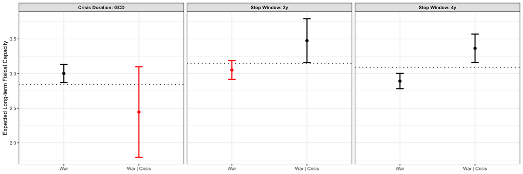

```r
# --------------------------------------------
# Plot EVs without linear-combo SEs (per request)
# --------------------------------------------
# For each model (facet):
#   • Dotted baseline at β0
#   • Two EV points:
#       - War          : ŷ = β0 + β_war          ; CI uses SE(β_war)
#       - War | Crisis : ŷ = β0 + β_war + β_cris ; CI uses SE(β_cris)
#   • Color rule (effect significance):
#       - War          : red if β_war CI crosses 0
#       - War | Crisis : red if β_cris CI crosses 0
# NOTE: This deliberately ignores covariance terms and any delta-method
#       linear-combination SEs (as requested).
# Build plotting rows for one model using only per-term SEs
ev_rows_no_lc <- function(model, crisis_var, war_var = "years_external", z = 1.96) {
  tt <- broom::tidy(model)

  # pull needed terms
  b0     <- tt$estimate[tt$term == "(Intercept)"]
  b_war  <- tt$estimate[tt$term == war_var]
  se_war <- tt$std.error[tt$term == war_var]
  b_cris  <- tt$estimate[tt$term == crisis_var]
  se_cris <- tt$std.error[tt$term == crisis_var]

  # EV point estimates
  mu_w  <- b0 + b_war
  mu_wc <- b0 + b_war + b_cris

  # CIs built ONLY from each term's own SE (no linear combinations)
  lb_w  <- mu_w  - z * se_war;  ub_w  <- mu_w  + z * se_war
  lb_wc <- mu_wc - z * se_cris; ub_wc <- mu_wc + z * se_cris

  # effect-significance colors (per-term)
  war_red  <- (b_war  - z * se_war  <= 0) & (b_war  + z * se_war  >= 0)
  cris_red <- (b_cris - z * se_cris <= 0) & (b_cris + z * se_cris >= 0)

  tibble::tibble(
    status   = factor(c("War","War | Crisis"), levels = c("War","War | Crisis")),
    estimate = c(mu_w, mu_wc),
    lb       = c(lb_w, lb_wc),
    ub       = c(ub_w, ub_wc),
    b0       = b0,
    color    = c(ifelse(war_red, "red", "black"),
                 ifelse(cris_red, "red", "black"))
  )
}

# --- Prepare all three panels (crisis var names as in your models) ---
mods <- list(
  `Stop Window: 4y` = list(m = m_stop4y, crisis = "total_years_war_and_stop_4y"),
  `Stop Window: 2y` = list(m = m_stop2y, crisis = "total_years_war_and_stop_2y"),
  `Crisis Duration: GCD`    = list(m = m_gcd,    crisis = "total_years_yr_stop_gcd")
)

df_all <- dplyr::bind_rows(lapply(names(mods), function(lbl) {
  with(mods[[lbl]], ev_rows_no_lc(m, crisis_var = crisis)) %>% dplyr::mutate(panel = lbl)
}))

# Shared y-limits (small padding)
ylim_all <- range(df_all$lb, df_all$ub, na.rm = TRUE)
pad <- if (is.finite(diff(range(ylim_all)))) diff(range(ylim_all))*0.05 else 0.05
ylim_all <- c(ylim_all[1] - pad, ylim_all[2] + pad)

# Baseline per panel
b0_df <- dplyr::distinct(df_all, panel, b0)

# --- Faceted plot (3 panels) ---
cs_compare  <- ggplot(df_all, aes(x = status, y = estimate)) +
              geom_hline(data = b0_df, aes(yintercept = b0),
                         linetype = "dotted", linewidth = 0.9, colour = "grey30") +
              geom_errorbar(aes(ymin = lb, ymax = ub, colour = color),
                            width = 0.10, linewidth = 1.05, show.legend = FALSE) +
              geom_point(aes(colour = color), size = 2.4, show.legend = FALSE) +
              scale_colour_identity() +
              facet_wrap(~panel, nrow = 1) +
              scale_y_continuous(limits = ylim_all, expand = expansion(mult = 0)) +
              labs(x = NULL, y = "Expected Long-term Fisical Capacity") +
              theme_bw(base_size = 12) +
              theme(
                strip.background = element_rect(fill = "grey90", colour = "black"),
                strip.text = element_text(face = "bold")
              )

cs_compare
```

```r
out_dir <- "/Users/jinwenwu/Dropbox/WS/output/graphs/cs_plot"
# ggsave(file.path(out_dir, "windows_duration_panel_1.png"),
#        cs_compare, width = 15, height = 5, dpi = 300)
# ggsave(file.path(out_dir, "windows_duration_panel_1.pdf"),
#        cs_compare, width = 15, height = 5, dpi = 300)
```

```r
# Check which panels are available
panels <- unique(df_all$panel)
print(panels)
```

```
## [1] "Stop Window: 4y"      "Stop Window: 2y"      "Crisis Duration: GCD"
```

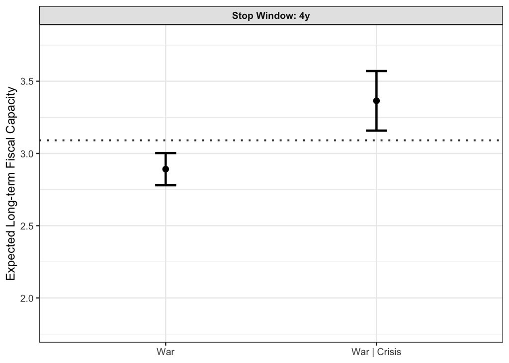

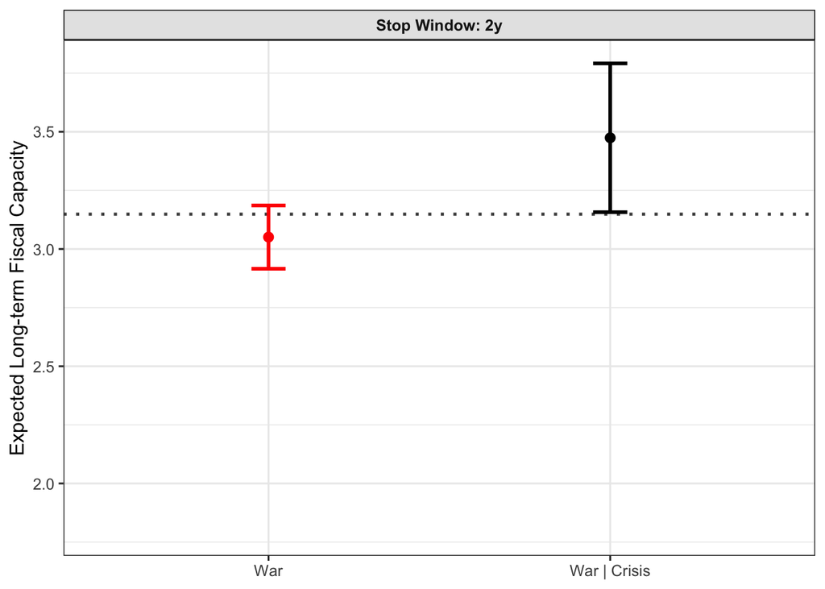

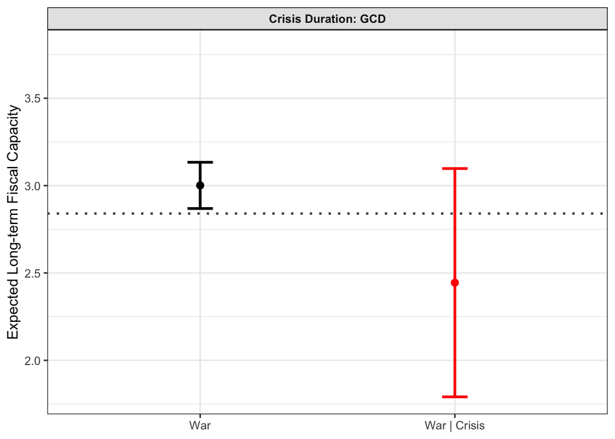

```r
to_fname <- function(x) str_replace_all(x, "[^A-Za-z0-9]+", "_")

# Loop through and display each plot
for (p in panels) {
  df_p <- df_all %>% filter(panel == p)
  b0_p <- b0_df  %>% filter(panel == p)

  g <- ggplot(df_p, aes(x = status, y = estimate)) +
    geom_hline(data = b0_p, aes(yintercept = b0),
               linetype = "dotted", linewidth = 0.9, colour = "grey30") +
    geom_errorbar(aes(ymin = lb, ymax = ub, colour = color),
                  width = 0.10, linewidth = 1.05, show.legend = FALSE) +
    geom_point(aes(colour = color), size = 2.4, show.legend = FALSE) +
    scale_colour_identity() +
    facet_wrap(~panel, nrow = 1) +
    scale_y_continuous(limits = ylim_all, expand = expansion(mult = 0)) +
    labs(x = NULL, y = "Expected Long-term Fiscal Capacity") +
    theme_bw(base_size = 12) +
    theme(
      strip.background = element_rect(fill = "grey90", colour = "black"),
      strip.text       = element_text(face = "bold")
    )

  print(g)  # display plot immediately
  #out_file <- file.path(out_dir, paste0("cs_compare_", to_fname(p), ".png"))
  # ggsave(out_file, plot = g, width = 5.2, height = 4.6, dpi = 300)
  #message("Saved: ", out_file)
}
```

### War and LT Effect

**Baseline war and w/o war-year**

```r
war_crisis <- war %>%
  # First filter to your desired time range
  filter(year >= 1816, year <= 1913) %>%
  # Then create complete country-year combinations
  complete(iso3, year = 1816:1913) %>%
  mutate(
    flag_RR   = as.integer(year %in% df_RR$Year),
    flag_GCD  = as.integer(year %in% df_GCD$Year),
    # Impute 0 for missing war status
    across(c(is_inter, is_intra), ~ ifelse(is.na(.), 0, .)),
    at_war = as.integer(is_inter == 1 | is_intra == 1)
  )
# --- cross-section ---
war_crisis_cs <- war_crisis %>%
  group_by(iso3) %>%
  summarise(
    yr_war   = sum(at_war,       na.rm = TRUE),
    yr_inter = sum(is_inter,  na.rm = TRUE),
    yr_intra = sum(is_intra,  na.rm = TRUE),
    yr_homeland = sum(homeland,  na.rm = TRUE),

    yr_in_crisis_RR        = sum(at_war      & flag_RR  == 1L, na.rm = TRUE),
    yr_in_crisis_RR_inter  = sum(is_inter & flag_RR  == 1L, na.rm = TRUE),
    yr_in_crisis_RR_intra  = sum(is_intra & flag_RR  == 1L, na.rm = TRUE),

    yr_in_crisis_GCD       = sum(at_war      & flag_GCD == 1L, na.rm = TRUE),
    yr_in_crisis_GCD_inter = sum(is_inter & flag_GCD == 1L, na.rm = TRUE),
    yr_in_crisis_GCD_intra = sum(is_intra & flag_GCD == 1L, na.rm = TRUE),
    .groups = "drop"
  )
# Impute 0 for missing values
war_crisis_cs[is.na(war_crisis_cs)] <- 0
```

```r
controls <- controls %>%
  mutate(
    iso3 = countrycode(
      sourcevar    = country,
      origin       = "country.name",
      destination  = "iso3c"
    )
  )
# ---- check unmatched countries ----
unmatched <- controls %>%
  filter(is.na(iso3)) %>%
  distinct(country) %>%
  arrange(country)
```

```r
controls_wc <- controls %>%
  left_join(war_crisis_cs, by = "iso3")

# Identify which columns in controls_wc are from war_crisis_cs
vars_from_war <- intersect(names(controls_wc), names(war_crisis_cs))

# Impute 0 for all NAs in those columns
controls_wc[vars_from_war] <- lapply(controls_wc[vars_from_war], function(x) {
  x[is.na(x)] <- 0
  x
})
```

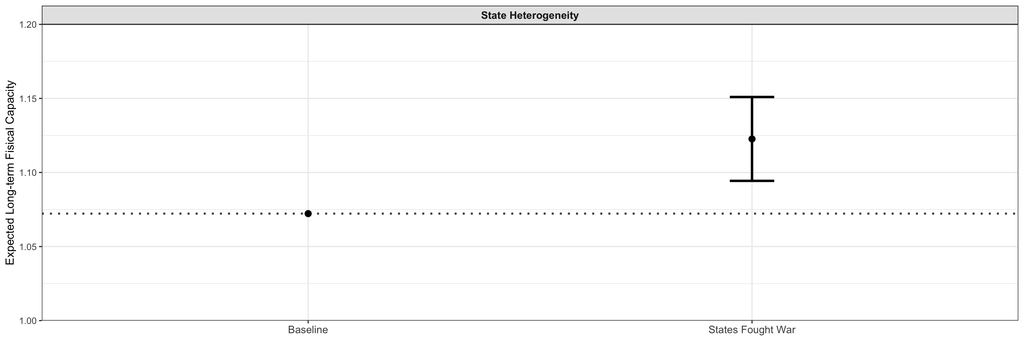

```r
m_war <- feols(
  as.formula(paste("avg_pit_95_05 ~  yr_war +", xctrl)),
  data = controls_wc,
  vcov = "HC1"
)

tt <- tidy(m_war)
war_var <- "yr_war"

# coefficients and SEs
b0   <- tt$estimate[tt$term == "(Intercept)"]
b1   <- tt$estimate[tt$term == war_var]
se1  <- tt$std.error[tt$term == war_var]
z    <- 1.96

# EV for "States Fought War" and its CI using ONLY SE(b1)
mu_war  <- b0 + b1
lb_war  <- mu_war - z * se1
ub_war  <- mu_war + z * se1

# plotting data: baseline has no CI (NA), war has CI
df_plot <- tibble(
  status   = factor(c("Baseline", "States Fought War"),
                    levels = c("Baseline", "States Fought War")),
  estimate = c(b0, mu_war),
  lb       = c(NA,  lb_war),
  ub       = c(NA,  ub_war)
)

df_plot_hdr <- df_plot %>% mutate(panel = "State Heterogeneity")

ylim = c(1, 1.2)

p1 <- ggplot(df_plot_hdr, aes(x = status, y = estimate)) +
      geom_hline(yintercept = b0, linetype = "dotted", colour = "grey30", linewidth = 1) +
      geom_errorbar(aes(ymin = lb, ymax = ub), width = 0.10, linewidth = 1.2, na.rm = TRUE) +
      geom_point(size = 2.8, na.rm = TRUE) +
      scale_y_continuous(limits = ylim, expand = expansion(mult = 0)) +
      facet_wrap(~ panel) +                               # <-- grey header via facet strip
      labs(x = NULL, y = "Expected Long-term Fisical Capacity") +   # title handled by strip
      theme_bw(base_size = 12) +
      theme(
        strip.background = element_rect(fill = "grey90", colour = "black"),
        strip.text       = element_text(size = 11, face = "bold"),
        axis.text.x      = element_text(size = 11),
        plot.title       = element_blank()
      )

p1
```

```r
# ggsave(file.path(out_dir, "cs_war_effect.png"), p1, width = 5.2, height = 4.6, dpi = 300)
# ggsave(file.path(out_dir, "cs_war_effect.pdf"), p1, width = 5.2, height = 4.6, dpi = 300)
```

```r
# Create individual plots and store them by name
g_gcd <- df_all %>% filter(panel == "Crisis Duration: GCD") %>%
  {
    b0_p <- b0_df %>% filter(panel == "Crisis Duration: GCD")
    g <- ggplot(., aes(x = status, y = estimate)) +
      geom_hline(data = b0_p, aes(yintercept = b0),
                 linetype = "dotted", linewidth = 0.9, colour = "grey30") +
      geom_errorbar(aes(ymin = lb, ymax = ub, colour = color),
                    width = 0.10, linewidth = 1.05, show.legend = FALSE) +
      geom_point(aes(colour = color), size = 2.4, show.legend = FALSE) +
      scale_colour_identity() +
      facet_wrap(~panel, nrow = 1) +
      scale_y_continuous(limits = ylim_all, expand = expansion(mult = 0)) +
      labs(x = NULL, y = "") +
      theme_bw(base_size = 12) +
      theme(
        strip.background = element_rect(fill = "grey90", colour = "black"),
        strip.text       = element_text(face = "bold")
      )
    g
  }

# --- g_2y (show grid; hide y labels/ticks) ---
g_2y <- df_all %>% filter(panel == "Stop Window: 2y") %>%
  {
    b0_p <- b0_df %>% filter(panel == "Stop Window: 2y")
    g <- ggplot(., aes(x = status, y = estimate)) +
      geom_hline(data = b0_p, aes(yintercept = b0),
                 linetype = "dotted", linewidth = 0.9, colour = "grey30") +
      geom_errorbar(aes(ymin = lb, ymax = ub, colour = color),
                    width = 0.10, linewidth = 1.05, show.legend = FALSE) +
      geom_point(aes(colour = color), size = 2.4, show.legend = FALSE) +
      scale_colour_identity() +
      facet_wrap(~panel, nrow = 1) +
      # keep breaks so gridlines draw
      scale_y_continuous(limits = ylim_all, expand = expansion(mult = 0)) +
      labs(x = NULL, y = NULL) +
      theme_bw(base_size = 12) +
      theme(
        strip.background = element_rect(fill = "grey90", colour = "black"),
        strip.text       = element_text(face = "bold"),
        axis.text.y      = element_blank(),   # hide labels
        axis.ticks.y     = element_blank(),   # hide ticks
        axis.title.y     = element_blank()    # hide title
      )
   g
  }

# --- g_4y (show grid; hide y labels/ticks) ---
g_4y <- df_all %>% filter(panel == "Stop Window: 4y") %>%
  {
    b0_p <- b0_df %>% filter(panel == "Stop Window: 4y")
    g <- ggplot(., aes(x = status, y = estimate)) +
      geom_hline(data = b0_p, aes(yintercept = b0),
                 linetype = "dotted", linewidth = 0.9, colour = "grey30") +
      geom_errorbar(aes(ymin = lb, ymax = ub, colour = color),
                    width = 0.10, linewidth = 1.05, show.legend = FALSE) +
      geom_point(aes(colour = color), size = 2.4, show.legend = FALSE) +
      scale_colour_identity() +
      facet_wrap(~panel, nrow = 1) +
      # keep breaks so gridlines draw
      scale_y_continuous(limits = ylim_all, expand = expansion(mult = 0)) +
      labs(x = NULL, y = NULL) +
      theme_bw(base_size = 12) +
      theme(
        strip.background = element_rect(fill = "grey90", colour = "black"),
        strip.text       = element_text(face = "bold"),
        axis.text.y      = element_blank(),
        axis.ticks.y     = element_blank(),
        axis.title.y     = element_blank()
      )
    g
  }
```

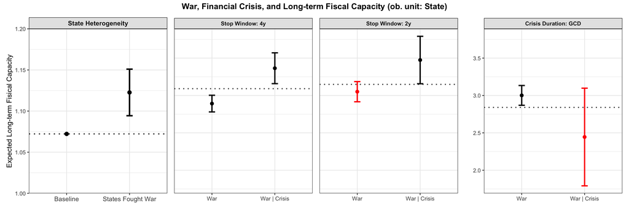

```r
final <- p1 + g_4y + g_2y + g_gcd +
  plot_layout(ncol = 4) +
  plot_annotation(title = "War, Financial Crisis, and Long-term Fiscal Capacity (ob. unit: State)", theme = theme(plot.title = element_text(face = "bold",
                                                          size = 14,
                                                          hjust = 0.5)))

print(final)
```

```r
ggsave("/Users/joey/Library/CloudStorage/Dropbox/WS/output/graphs/cs_plot/cs_final.png", final, width = 15, height = 5, dpi = 300)
ggsave("/Users/joey/Library/CloudStorage/Dropbox/WS/output/graphs/cs_plot/cs_final.pdf", final, width = 15, height = 5, dpi = 300)
```

## Table 5: War Finance CS design.

```r
ccwp <- read.csv("../data/CCWP/CCWP-Data.csv")
```

`wtax` | War Tax: tax revenues specifically earmarked for the war effort. |  
`domtax` | Domestic Taxation: share of war paid for out of domestic tax revenues. |  
`domwf` | Domestic War Finance: all domestic revenues including taxation, existing coffers, domestic borrowing, and printing money. |  
`mnyabrd` | External Funding: war financed by sources from abroad, including plunder, grants, loans, or aid. |  
`totalbrw` | Total Borrow: total amount borrowed to finance war, both domestic and foreign.

```r
ccwp_pre_1995 <- ccwp %>%
  filter (yrend1 <= 1995)
```

```r
ccwp_expanded <- ccwp_pre_1995 %>%
  rowwise() %>%
  mutate(year = list(seq(yrbeg1, yrend1))) %>%
  unnest(year)

# 2. Collapse back to cross-section (one row per stateabb)
state_summary <- ccwp_expanded %>%
  group_by(stateabb) %>%
  summarise(
    total_waryears = n(),  # Total years at war

    # 3. Tax-based war-years
    half_tax = sum(domtax > 2, na.rm = TRUE),
    tax25    = sum(domtax > 1, na.rm = TRUE),

    # 4. Any war-year with foreign borrowing (binary brwabrdyn)
    any_borrow_abroad = sum(brwabrdyn == 1, na.rm = TRUE),

    # 5. Borrowing intensity
    half_borrow = sum(totalbrw > 2, na.rm = TRUE),
    borrow25    = sum(totalbrw > 1, na.rm = TRUE),

    # 6. External Soource intensity
    half_ext = sum(mnyabrd > 2, na.rm = TRUE),
    ext25    = sum(mnyabrd > 1, na.rm = TRUE)

  )


# 3. Merge by country code
ccwp_use <- full_join(controls, state_summary, by = c("iso3" = "stateabb"))

# 4. Replace NA in war-related variables with 0
war_vars <- c("total_waryears", "half_tax", "tax25", "half_ext", "ext25",
              "any_borrow_abroad", "half_borrow", "borrow25")

ccwp_use[war_vars] <- lapply(ccwp_use[war_vars], function(x) ifelse(is.na(x), 0, x))
ccwp_use[num_ctrls] <- lapply(ccwp_use[num_ctrls], function(v) v - mean(v, na.rm = TRUE))
```

```r
m_25_tax <- feols(
  as.formula(paste("avg_pit_95_05 ~  total_waryears +  tax25 +", xctrl)),
  data = ccwp_use,
  vcov = "HC1"
)
```

```
## NOTE: 21 observations removed because of NA values (LHS: 21, RHS: 21).
```

```r
m_half_tax <- feols(
  as.formula(paste("avg_pit_95_05 ~ total_waryears +  half_tax +", xctrl)),
  data = ccwp_use,
  vcov = "HC1"
)
```

```
## NOTE: 21 observations removed because of NA values (LHS: 21, RHS: 21).
```

```r
any_borrow <- feols(
  as.formula(paste("avg_pit_95_05 ~ total_waryears +  any_borrow_abroad +", xctrl)),
  data = ccwp_use,
  vcov = "HC1"
)
```

```
## NOTE: 21 observations removed because of NA values (LHS: 21, RHS: 21).
```

```r
m_25_borrow <- feols(
  as.formula(paste("avg_pit_95_05 ~  total_waryears +   borrow25 +", xctrl)),
  data = ccwp_use,
  vcov = "HC1"
)
```

```
## NOTE: 21 observations removed because of NA values (LHS: 21, RHS: 21).
```

```r
m_half_borrow <- feols(
  as.formula(paste("avg_pit_95_05 ~  total_waryears +  half_borrow +", xctrl)),
  data = ccwp_use,
  vcov = "HC1"
)
```

```
## NOTE: 21 observations removed because of NA values (LHS: 21, RHS: 21).
```

```r
m_25_ext <- feols(
  as.formula(paste("avg_pit_95_05 ~  total_waryears +   ext25 +", xctrl)),
  data = ccwp_use,
  vcov = "HC1"
)
```

```
## NOTE: 21 observations removed because of NA values (LHS: 21, RHS: 21).
```

```r
m_half_ext<- feols(
  as.formula(paste("avg_pit_95_05 ~  total_waryears +  half_ext +", xctrl)),
  data = ccwp_use,
  vcov = "HC1"
)
```

```
## NOTE: 21 observations removed because of NA values (LHS: 21, RHS: 21).
```

```r
m_ccwp_baseline <- feols(
  as.formula(paste("avg_pit_95_05 ~  total_waryears +", xctrl)),
  data = ccwp_use,
  vcov = "HC1"
)
```

```
## NOTE: 21 observations removed because of NA values (LHS: 21, RHS: 21).
```

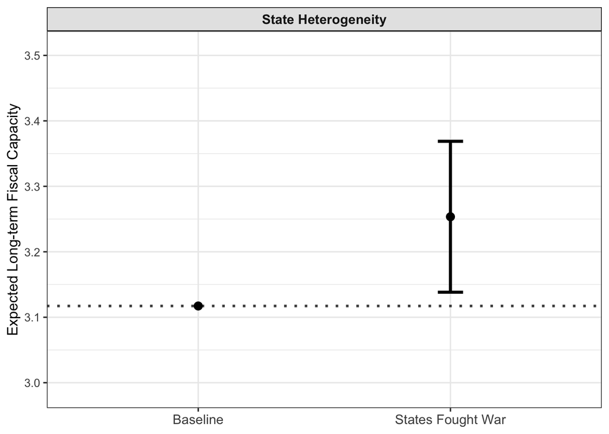

```r
# 3. Extract coefficients
tt <- tidy(m_ccwp_baseline)
war_var <- "total_waryears"

b0   <- tt$estimate[tt$term == "(Intercept)"]
b1   <- tt$estimate[tt$term == war_var]
se1  <- tt$std.error[tt$term == war_var]
z    <- 1.96

mu_war  <- b0 + b1
lb_war  <- mu_war - z * se1
ub_war  <- mu_war + z * se1

df_plot <- tibble(
  status   = factor(c("Baseline", "States Fought War"),
                    levels = c("Baseline", "States Fought War")),
  estimate = c(b0, mu_war),
  lb       = c(NA,  lb_war),
  ub       = c(NA,  ub_war),
  panel    = "State Heterogeneity"
)

# Dynamically set plotting range
ylim <- range(c(lb_war, ub_war, b0), na.rm = TRUE) * c(0.95, 1.05)

p1_wf <- ggplot(df_plot, aes(x = status, y = estimate)) +
  geom_hline(yintercept = b0, linetype = "dotted", colour = "grey30", linewidth = 1) +
  geom_errorbar(aes(ymin = lb, ymax = ub), width = 0.10, linewidth = 1.2, na.rm = TRUE) +
  geom_point(size = 2.8, na.rm = TRUE) +
  scale_y_continuous(limits = ylim, expand = expansion(mult = 0)) +
  facet_wrap(~ panel) +
  labs(x = NULL, y = "Expected Long-term Fiscal Capacity") +
  theme_bw(base_size = 12) +
  theme(
    strip.background = element_rect(fill = "grey90", colour = "black"),
    strip.text       = element_text(size = 11, face = "bold"),
    axis.text.x      = element_text(size = 11),
    plot.title       = element_blank()
  )

p1_wf
```

```r
# --- Build EV rows for each model separately ---
ev_half_tax <- ev_rows_no_lc(m_half_tax, crisis_var = "half_tax", war_var = "total_waryears")
ev_half_ext <- ev_rows_no_lc(m_half_ext, crisis_var = "half_ext", war_var = "total_waryears")
ev_any_borrow <- ev_rows_no_lc(any_borrow, crisis_var = "any_borrow_abroad", war_var = "total_waryears")

# --- Combine with labels for plotting ---
df_ev_all <- bind_rows(
  ev_half_tax %>% mutate(panel = "Taxation Share > 50%",
                         status = factor(c("War", "War | Taxation"),
                                         levels = c("War", "War | Taxation"))),
  ev_half_ext %>% mutate(panel = "External Share > 50%",
                         status = factor(c("War", "War | External Sources"),
                                         levels = c("War", "War | External Sources"))),
  ev_any_borrow %>% mutate(panel = "Any Foreign Borrowing",
                           status = factor(c("War", "War | Ever Borrowed Abroad"),
                                           levels = c("War", "War | Ever Borrowed Abroad")))
)


make_single_plot <- function(data, panel_name, ylim_all = NULL, show_y_numbers = TRUE) {
  df_panel <- data %>% filter(panel == panel_name)
  b0_val   <- unique(df_panel$b0)

  # Helper for conditional axis styling
  y_breaks  <- if (show_y_numbers) waiver() else NULL
  y_labels  <- if (show_y_numbers) waiver() else NULL
  y_text    <- if (show_y_numbers) element_text() else element_blank()
  y_ticks   <- if (show_y_numbers) element_line() else element_blank()
  y_title   <- if (show_y_numbers) element_text() else element_blank()

  ggplot(df_panel, aes(x = status, y = estimate)) +
    geom_hline(yintercept = b0_val, linetype = "dotted",
               linewidth = 0.9, colour = "grey30") +
    geom_errorbar(aes(ymin = lb, ymax = ub, colour = color),
                  width = 0.10, linewidth = 1.05, show.legend = FALSE) +
    geom_point(aes(colour = color), size = 2.4, show.legend = FALSE) +
    scale_colour_identity() +
    facet_wrap(~panel, nrow = 1) +
    scale_y_continuous(limits = ylim_all,
                       expand = expansion(mult = 0),
                       breaks = y_breaks, labels = y_labels) +
    labs(x = NULL, y = NULL) +
    theme_bw(base_size = 12) +
    theme(
      strip.background = element_rect(fill = "grey90", colour = "black"),
      strip.text       = element_text(face = "bold"),
      axis.text.y      = y_text,
      axis.ticks.y     = y_ticks,
      axis.title.y     = y_title
    )}

g_tax   <- make_single_plot(df_ev_all, ylim_all = c(1.5, 4), "Taxation Share > 50%")
g_ext   <- make_single_plot(df_ev_all, ylim_all = c(1.5, 4),  "External Share > 50%", show_y_numbers = FALSE)
g_borr  <- make_single_plot(df_ev_all, ylim_all = c(1.5, 4), "Any Foreign Borrowing", show_y_numbers = FALSE)
```

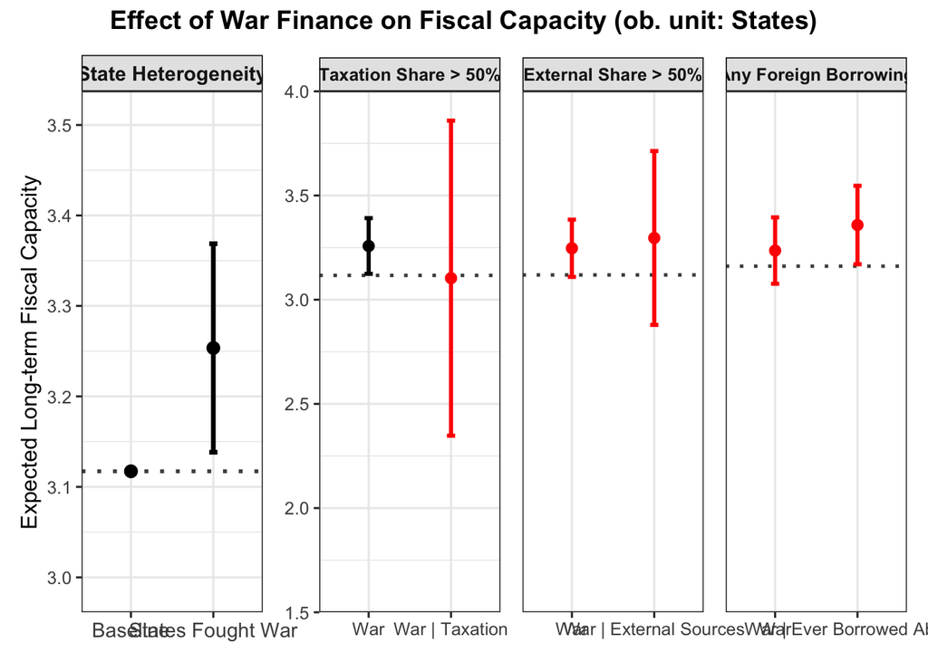

```r
final_wf <- p1_wf + g_tax + g_ext + g_borr +
  plot_layout(ncol = 4) +
  plot_annotation(title = "Effect of War Finance on Fiscal Capacity (ob. unit: States)", theme = theme(plot.title = element_text(face = "bold",
                                                          size = 14,
                                                          hjust = 0.5)))

print(final_wf)
```

```r
ggsave("/Users/joey/Library/CloudStorage/Dropbox/WS/output/graphs/cs_plot/wf_final.png", final_wf, width = 15, height = 5, dpi = 300)
ggsave("/Users/joey/Library/CloudStorage/Dropbox/WS/output/graphs/cs_plot/wf_final.pdf", final_wf, width = 15, height = 5, dpi = 300)
```

# Cluster

```r
# 1. Define the keys you will join the dataframes by
join_keys <- c("cowcode", "country")

# 2. Programmatically find the overlapping column names
#    This finds all columns that are in BOTH dataframes.
common_cols <- intersect(names(Queralt_cs), names(controls_wc))

# 3. Create a list of columns to DROP from the right-hand dataframe ('controls_wc')
#    This is the list of common columns, MINUS the keys we need for joining.
cols_to_drop <- setdiff(common_cols, join_keys)

# 4. Perform the full join
join_keys <- c("cowcode")

df0 <- full_join(
  Queralt_cs_dm %>%
    dplyr::select(-any_of(c("country.x", "country.y"))),
  controls_wc %>%
    dplyr::select(-any_of(cols_to_drop)),
  by = join_keys
)
```

```r
# Feature groups
vars_war <- intersect(c(
  "years_external","total_years_war_and_flow_4y","total_years_war_and_stop_4y",
  "yr_inter","yr_intra","yr_in_flow_rr_inter","yr_in_crisis_RR_inter",
  "yr_in_flow_gcd_inter","yr_in_crisis_GCD_inter", "yr_homeland"
), names(df0))

vars_capacity <- intersect(c(
  "first_census","census_1820","census_1914",
  "ln_rail_km_1850","rail_km_1850",
  "pop_dens_1820","statehist05v3"
), names(df0))

vars_geo <- intersect(c("land_area_scaled","near_coast","rugged","desert","tropical"), names(df0))

vars_colonial <- intersect(c("colony_any","colony_iberia","colony_other","colony_uk","greatpower"), names(df0))

vars_alliance <- intersect(c("share_alliance_france","share_alliance_ger","share_alliance_uk","share_alliance_usa"), names(df0))

feat_all <- c(vars_war, vars_capacity, vars_geo, vars_colonial, vars_alliance)

X <- df0 %>% select(all_of(feat_all))
```

```r
# For record only
# drop_vars_bigNA <- c("exconst_1800_1830","local_democracy","exconst_1800_1850","exconst_1900_13","ln_rail_km_1913","primary_1820")

drop_countries  <- c("Namibia","Lebanon","Bhutan", "United Kingdom")

df0 <- df0 %>%
  filter(!(country %in% drop_countries))

feat_nowar <- c(vars_capacity, vars_geo, vars_colonial, vars_alliance)
feat_withwar <- c(vars_war, feat_nowar)
```

```r
# =======================================================================================
# == NO_WAR SPEC  =====================
# =======================================================================================

# Select features (no imputation). We enforce completeness:
X_nowar <- df0[, feat_nowar, drop = FALSE] |> as.data.frame()
rownames(X_nowar) <- df0$country
stopifnot(!anyNA(X_nowar))      # If NA exists, stop. Nothing is imputed.

# Identify strict numeric binaries (0/1). These are treated as:
#   - factors for FAMD (so they enter as categorical),
#   - numeric 0/1 for Gower (so 'asymm' works correctly).
bin_cols_nowar <- names(X_nowar)[sapply(X_nowar, function(z) is.numeric(z) && all(na.omit(z) %in% c(0,1)))]

# --- A) FAMD + k-means ---------------------------------------------------------------
# FAMD (Pagès 2014; Lê, Josse & Husson 2008) handles mixed data by standardizing
# quantitative vars and using appropriate coding for factors.
# Here: we coerce 0/1 to factors ONLY for FAMD input. No scaling choices by us;
# FAMD standardizes internally. No imputation occurs.
Xf_nowar <- X_nowar
if (length(bin_cols_nowar)) {
  for (nm in bin_cols_nowar) Xf_nowar[[nm]] <- factor(Xf_nowar[[nm]], levels = c(0,1))
}
famd_nowar <- FactoMineR::FAMD(Xf_nowar, ncp = max(2, min(10, ncol(Xf_nowar)-1)), graph = FALSE)

# Choose dimensionality: keep enough axes to reach ≥80% cumulative inertia (variance share).
perc_nowar <- famd_nowar$eig[,2]
dopt_nowar <- which(cumsum(perc_nowar) >= 80)[1]; if (is.na(dopt_nowar)) dopt_nowar <- min(2, ncol(famd_nowar$ind$coord))
S_nowar <- famd_nowar$ind$coord[, 1:dopt_nowar, drop = FALSE]
# low-dim scores used for clustering

# k-means on the low-dim scores. k is chosen by maximizing silhouette (Rousseeuw 1987) over 2..8.
distS_nowar <- dist(S_nowar)
k_grid <- 2:8
sil_vals_FAMD_nowar <- numeric(length(k_grid))
km_models_nowar <- vector("list", length(k_grid))
for (i in seq_along(k_grid)) {
  k <- k_grid[i]
  km <- kmeans(S_nowar, centers = k, nstart = 50)
  km_models_nowar[[i]] <- km
  if (length(unique(km$cluster)) >= 2) {
    sil_vals_FAMD_nowar[i] <- mean(silhouette(as.integer(km$cluster), distS_nowar)[,3])
  } else sil_vals_FAMD_nowar[i] <- NA_real_
}
best_i_FAMD_nowar <- which.max(sil_vals_FAMD_nowar)
km_best_nowar <- km_models_nowar[[best_i_FAMD_nowar]]
cl_FAMD_nowar <- factor(km_best_nowar$cluster)          # INTERPRETATION: cluster labels from FAMD+kmeans
sil_FAMD_nowar <- sil_vals_FAMD_nowar[best_i_FAMD_nowar]# INTERPRETATION: mean silhouette ∈ [-1,1]; higher = better separation
k_FAMD_nowar <- length(unique(cl_FAMD_nowar))           # chosen k

# --- B) Gower + PAM -------------------------------------------------------------------
# Gower distance (Gower 1971) handles mixed types; we keep binaries numeric 0/1 and declare
# them asymmetric ('asymm') so mismatches on 1's count more than 0-0 matches.
# Weights: set to 2 for war vars (if present), else 1. No imputation.
Xg_nowar <- X_nowar
Xg_nowar[, c(14, 15, 16)] <- lapply(Xg_nowar[, c(14, 15, 16)], factor)
w_nowar <- setNames(rep(1, ncol(Xg_nowar)), colnames(Xg_nowar))
war_names_nowar <- intersect(vars_war, colnames(Xg_nowar))  # empty by design in NO_WAR spec
if (length(war_names_nowar)) w_nowar[war_names_nowar] <- 2

Dg_nowar <- cluster::daisy(Xg_nowar, metric = "gower",
                           weights = w_nowar[colnames(Xg_nowar)],
                           type = if (length(bin_cols_nowar)) list(asymm = bin_cols_nowar) else NULL)

# PAM (Kaufman & Rousseeuw 1990) on Gower dissimilarities. k chosen by silhouette over 2..8.
sil_vals_PAM_nowar <- numeric(length(k_grid))
pam_models_nowar <- vector("list", length(k_grid))
for (i in seq_along(k_grid)) {
  k <- k_grid[i]
  fit <- pam(Dg_nowar, k, diss = TRUE)
  pam_models_nowar[[i]] <- fit
  sil_vals_PAM_nowar[i] <- fit$silinfo$avg.width
}
best_i_PAM_nowar <- which.max(sil_vals_PAM_nowar)
pam_best_nowar <- pam_models_nowar[[best_i_PAM_nowar]]
cl_PAM_nowar <- factor(pam_best_nowar$clustering)       # INTERPRETATION: cluster labels from Gower+PAM
sil_PAM_nowar <- pam_best_nowar$silinfo$avg.width       # INTERPRETATION: PAM’s average silhouette
k_PAM_nowar <- length(unique(cl_PAM_nowar))
```

```r
# =======================================================================================
# == WITH_WAR SPEC (same pipeline; weights↑ on war vars in Gower; eta^2 diagnostic) =====
# =======================================================================================

X_with <- df0[, feat_withwar, drop = FALSE] |> as.data.frame()
rownames(X_with) <- df0$country
stopifnot(!anyNA(X_with))       # Again: no imputation; abort if NA.

bin_cols_with <- names(X_with)[sapply(X_with, function(z) is.numeric(z) && all(na.omit(z) %in% c(0,1)))]

# --- A) FAMD + k-means ----------------------------------------------------------------
Xf_with <- X_with
if (length(bin_cols_with)) {
  for (nm in bin_cols_with) Xf_with[[nm]] <- factor(Xf_with[[nm]], levels = c(0,1))
}
famd_with <- FactoMineR::FAMD(Xf_with, ncp = max(2, min(10, ncol(Xf_with)-1)), graph = FALSE)
perc_with <- famd_with$eig[,2]
dopt_with <- which(cumsum(perc_with) >= 80)[1]; if (is.na(dopt_with)) dopt_with <- min(2, ncol(famd_with$ind$coord))
S_with <- famd_with$ind$coord[, 1:dopt_with, drop = FALSE]

distS_with <- dist(S_with)
sil_vals_FAMD_with <- numeric(length(k_grid))
km_models_with <- vector("list", length(k_grid))
for (i in seq_along(k_grid)) {
  k <- k_grid[i]
  km <- kmeans(S_with, centers = k, nstart = 50)
  km_models_with[[i]] <- km
  if (length(unique(km$cluster)) >= 2) {
    sil_vals_FAMD_with[i] <- mean(silhouette(as.integer(km$cluster), distS_with)[,3])
  } else sil_vals_FAMD_with[i] <- NA_real_
}
best_i_FAMD_with <- which.max(sil_vals_FAMD_with)
km_best_with <- km_models_with[[best_i_FAMD_with]]
cl_FAMD_with <- factor(km_best_with$cluster)            # cluster labels (WITH_WAR; FAMD route)
sil_FAMD_with <- sil_vals_FAMD_with[best_i_FAMD_with]
k_FAMD_with <- length(unique(cl_FAMD_with))

# --- B) Gower + PAM -------------------------------------------------------------------
Xg_with <- X_with
Xg_with[, c(21, 22, 23)] <- lapply(Xg_with[, c(21, 22, 23)], factor)

w_with <- setNames(rep(1, ncol(Xg_with)), colnames(Xg_with))
war_names_with <- intersect(vars_war, colnames(Xg_with))
Dg_with <- cluster::daisy(Xg_with, metric = "gower",
                          weights = w_with[colnames(Xg_with)],
                          type = if (length(bin_cols_with)) list(asymm = bin_cols_with) else NULL)
sil_vals_PAM_with <- numeric(length(k_grid))
pam_models_with <- vector("list", length(k_grid))
for (i in seq_along(k_grid)) {
  k <- k_grid[i]
  fit <- pam(Dg_with, k, diss = TRUE)
  pam_models_with[[i]] <- fit
  sil_vals_PAM_with[i] <- fit$silinfo$avg.width
}
best_i_PAM_with <- which.max(sil_vals_PAM_with)
pam_best_with <- pam_models_with[[best_i_PAM_with]]
cl_PAM_with <- factor(pam_best_with$clustering)         # cluster labels (WITH_WAR; Gower+PAM)
sil_PAM_with <- pam_best_with$silinfo$avg.width
k_PAM_with <- length(unique(cl_PAM_with))
```

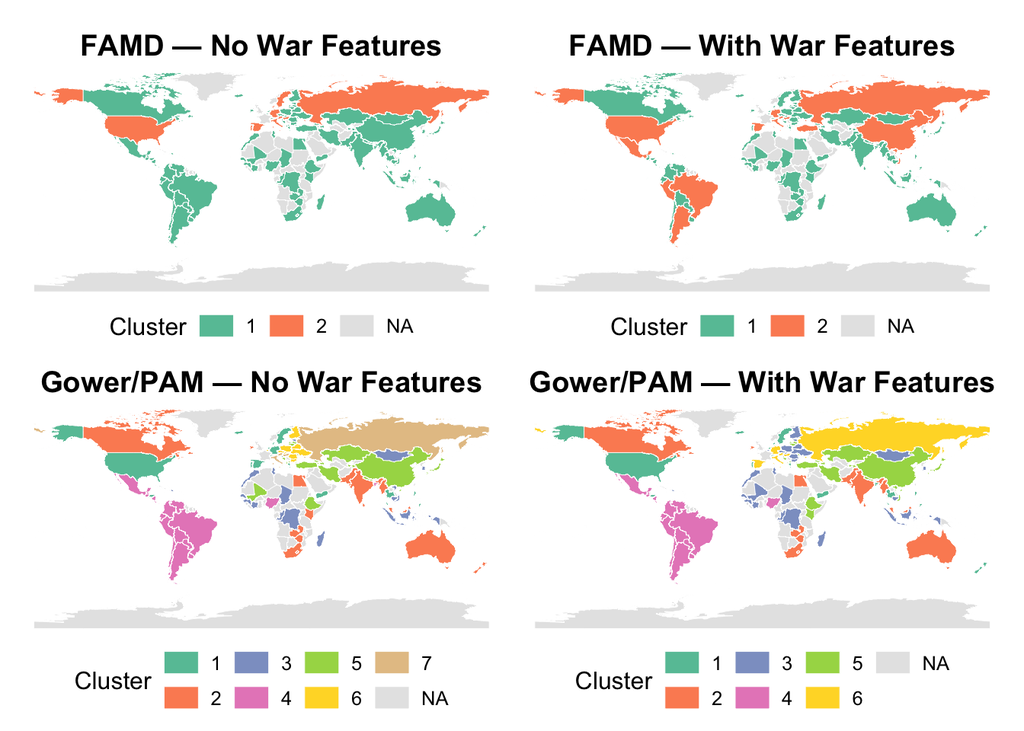

```r
# Packages
library(dplyr)
library(tidyr)
library(ggplot2)
library(sf)
library(countrycode)
library(rnaturalearth)
library(rnaturalearthdata)
library(patchwork)
library(clue)   # for Hungarian assignment to align labels

# ---------- 0) Helpers ----------
# Align cluster labels in 'alt' to match 'base' (solve label switching)
align_clusters <- function(base, alt) {
  base <- factor(base)
  alt  <- factor(alt)
  tab  <- table(base, alt)                         # contingency
  m    <- as.matrix(tab)
  # pad to square if needed
  if (nrow(m) != ncol(m)) {
    k <- max(nrow(m), ncol(m))
    m2 <- matrix(0, nrow = k, ncol = k)
    m2[seq_len(nrow(m)), seq_len(ncol(m))] <- m
    m <- m2; rownames(m) <- paste0("b", seq_len(k)); colnames(m) <- paste0("a", seq_len(k))
  }
  match_alt <- solve_LSAP(m, maximum = TRUE)       # permutation
  lut <- setNames(seq_along(match_alt), names(match_alt)) # alt-level -> permuted index
  # Build mapping from original alt levels to base levels
  alt_lvls <- levels(alt)
  base_lvls <- levels(base)
  # map through contingency names if padded:
  if (all(grepl("^b\\d+$", rownames(m)))) {
    # fall back to numeric labels
    new_alt <- as.integer(alt)
  } else {
    map_to <- base_lvls[match_alt[ match(alt_lvls, colnames(tab)) ]]
    names(map_to) <- alt_lvls
    new_alt <- unname(map_to[as.character(alt)])
  }
  factor(new_alt)
}

# Plot a world map for a given clustering (expects columns iso3c, cluster)
plot_cluster_map <- function(df_map, title) {
  world <- rnaturalearth::ne_countries(scale = "medium", returnclass = "sf") |>
    sf::st_transform(4326) |>
    dplyr::select(iso_a3, geometry)

  gdat <- world |>
    dplyr::left_join(df_map |> mutate(cluster = factor(cluster)), by = c("iso_a3" = "iso3c"))

  ggplot2::ggplot(gdat) +
    ggplot2::geom_sf(aes(fill = cluster), color = "white", size = 0.15) +
    ggplot2::scale_fill_brewer(palette = "Set2", na.value = "grey90", name = "Cluster") +
    ggplot2::labs(title = title, x = NULL, y = NULL) +
    ggplot2::theme_void(base_size = 12) +
    ggplot2::theme(
      plot.title = element_text(hjust = 0.5, face = "bold"),
      legend.position = "bottom",
      legend.key.height = unit(4, "mm")
    )
}



# Plot change (unchanged vs changed) between two clusterings (expects iso3c, changed)
plot_change_map <- function(df_change, title) {
  # Base map
  world <- ne_countries(scale = "medium", returnclass = "sf") |>
    st_transform(4326) |>
    select(iso_a3, geometry)

  gdat <- world |> left_join(df_change, by = c("iso_a3" = "iso3c"))

  # Centroids for changed states
  changed_centroids <- gdat |>
    filter(changed == TRUE & !st_is_empty(geometry)) |>
    st_centroid() |>
    mutate(
      lon = st_coordinates(geometry)[,1],
      lat = st_coordinates(geometry)[,2]
    )

  ggplot(gdat) +
    geom_sf(aes(fill = changed), color = "white", size = 0.15) +
    scale_fill_manual(
      values = c(`FALSE` = "#1f78b4", `TRUE` = "red"),
      labels = c(`FALSE` = "Unchanged", `TRUE` = "Changed"),
      na.value = "grey90",
      name = NULL
    ) +
    # Country labels like in the war‐finance figure
    geom_label_repel(
      data = changed_centroids,
      aes(x = lon, y = lat, label = iso_a3),
      size = 3.2,
      fontface = "bold",
      color = "black",
      fill = "white",
      label.size = 0.4,
      label.r = unit(0.15, "lines"),
      box.padding = 0.35,
      point.padding = 0.25,
      segment.color = NA,
      seed = 1234
    ) +
    labs(title = title, x = NULL, y = NULL) +
    theme_void(base_size = 12) +
    theme(
      plot.title = element_text(hjust = 0.5, face = "bold"),
      legend.position = "bottom",
      legend.key.height = unit(4, "mm")
    )
}

# ---------- 1) Store cluster results (country) ----------
# Build a base id frame
id_df <- df0 %>%
  transmute(
    country,
    cowcode = cowcode,   # use existing column
    iso3c = countrycode(country, "country.name", "iso3c", warn = FALSE)
  )

res_FAMD_nowar <- id_df %>% mutate(cluster = as.integer(cl_FAMD_nowar), model = "FAMD_NO_WAR")
res_PAM_nowar  <- id_df %>% mutate(cluster = as.integer(cl_PAM_nowar),  model = "PAM_NO_WAR")
res_FAMD_with  <- id_df %>% mutate(cluster = as.integer(cl_FAMD_with),  model = "FAMD_WITH_WAR")
res_PAM_with   <- id_df %>% mutate(cluster = as.integer(cl_PAM_with),   model = "PAM_WITH_WAR")

clusters_all <- bind_rows(res_FAMD_nowar, res_PAM_nowar, res_FAMD_with, res_PAM_with)

# ---------- 2) Four maps ----------
p1 <- plot_cluster_map(res_FAMD_nowar  %>% select(iso3c, cluster), "FAMD — No War Features")
p2 <- plot_cluster_map(res_FAMD_with   %>% select(iso3c, cluster), "FAMD — With War Features")
p3 <- plot_cluster_map(res_PAM_nowar   %>% select(iso3c, cluster), "Gower/PAM — No War Features")
p4 <- plot_cluster_map(res_PAM_with    %>% select(iso3c, cluster), "Gower/PAM — With War Features")

# Example layout (2x2)
(p1 + p2) / (p3 + p4)
```

```r
# Align cluster labels between specs
cl_FAMD_with_aligned <- align_clusters(cl_FAMD_nowar, cl_FAMD_with)
cl_PAM_with_aligned  <- align_clusters(cl_PAM_nowar,  cl_PAM_with)


# ---------- 3) Change maps: WITH_WAR vs NO_WAR (same format as attachment) ----------
# Align labels before comparing (label switching)
# Use NO_WAR as baseline for each method
chg_FAMD <- id_df %>%
  transmute(
    iso3c,
    changed = as.logical(as.integer(cl_FAMD_nowar) != as.integer(cl_FAMD_with_aligned))
  )

chg_PAM <- id_df %>%
  transmute(
    iso3c,
    changed = as.logical(as.integer(cl_PAM_nowar) != as.integer(cl_PAM_with_aligned))
  )


# ---------- 4) Annotate clusters back to df0 by ccode/cowcode ----------
df0 <- df0 %>%
  mutate(
    cl_FAMD_nowar = as.integer(cl_FAMD_nowar),
    cl_PAM_nowar  = as.integer(cl_PAM_nowar),
    cl_FAMD_with  = as.integer(cl_FAMD_with_aligned),   # aligned labels stored
    cl_PAM_with   = as.integer(cl_PAM_with_aligned)
  )
```

```r
# Plot a world map for a given clustering (expects columns iso3c, cluster)
plot_cluster_map <- function(df_map, title) {
  world <- rnaturalearth::ne_countries(scale = "medium", returnclass = "sf") |>
    sf::st_transform(4326) |>
    dplyr::select(iso_a3, geometry)

  gdat <- world |>
    dplyr::left_join(df_map |> mutate(cluster = factor(cluster)), by = c("iso_a3" = "iso3c"))

  # Get unique clusters
  num_clusters <- nlevels(gdat$cluster)

  # Define colors based on the number of clusters
  fill_colors <- c()
  if (num_clusters == 2) {
    fill_colors <- c("#1f78b4", "red")
  } else {
    fill_colors <- RColorBrewer::brewer.pal(num_clusters, "Set2")
  }

  ggplot2::ggplot(gdat) +
    ggplot2::geom_sf(aes(fill = cluster), color = "white", size = 0.15) +
    ggplot2::scale_fill_manual(values = fill_colors, na.value = "grey90", name = "Cluster") +
    ggplot2::labs(title = title, x = NULL, y = NULL) +
    ggplot2::theme_void(base_size = 12) +
    ggplot2::theme(
      plot.title = element_text(hjust = 0.5, face = "bold"),
      legend.position = "bottom",
      legend.key.height = unit(4, "mm")
    )
}
```

```r
p1 <- plot_cluster_map(res_FAMD_nowar  %>% select(iso3c, cluster), "Cluster Status (FAMD) by State Features ")
```

```r
# pc1 <- plot_change_map(df0, "Cluster Dynamaics (FAMD) with War History")
# ggsave("/Users/joey/Library/CloudStorage/Dropbox/WS/output/graphs/maps/map.png", pc1, width = 10, height = 5, dpi = 300)
# ggsave("/Users/joey/Library/CloudStorage/Dropbox/WS/output/graphs/maps/map.png", pc1, width = 10, height = 5, dpi = 300)
```

```r
df_box <- df0 %>%
  left_join(
    clusters_all %>%
      filter(model == "FAMD_NO_WAR") %>%
      select(country, cluster),
    by = "country"
  ) %>%
  left_join(
    chg_FAMD %>%
      select(iso3c, changed),
    by = c("iso3" = "iso3c")   # ✅ fix: match df0$iso3 to chg_FAMD$iso3c
  ) %>%
  filter(!is.na(avg_pit_95_05), !is.na(cluster))

p_box_1 <- ggplot(df_box, aes(x = factor(cluster), y = avg_pit_95_05)) +
  geom_boxplot(color = "black", fill = "white", outlier.shape = NA) +
  geom_jitter(
    aes(color = changed, size = changed),
    width = 0.15,
    alpha = 0.9
  ) +
  scale_color_manual(values = c("TRUE" = "red", "FALSE" = "#1f78b4")) +
  scale_size_manual(values = c("TRUE" = 2, "FALSE" = 1.25), guide = "none") +
  labs(
    x = "Cluster (FAMD, No War Spec)",
    y = "Average PIT (1995–2005)",
    title = "Distribution of avg_pit_95_05 by Cluster"
  ) +
  theme_bw(base_size = 13) +
  theme(
    plot.title = element_text(hjust = 0.5, face = "bold"),
    legend.position = "none"
  )
```

```r
p_box <- df_box %>%
  mutate(
    cluster_label = ifelse(cluster == 1, "Developing Fiscal States", "Advanced Fiscal States"),
    .strip = "Fiscal Capacity in 2000s by Cluster"
  ) %>%
  ggplot(aes(x = factor(cluster_label, levels = c("Developing Fiscal States", "Advanced Fiscal States")),
             y = avg_pit_95_05)) +
  geom_boxplot(aes(color = cluster_label),
               fill = "white", outlier.shape = NA, linewidth = 0.8) +
  geom_jitter(
    aes(color = ifelse(changed, "Changed", cluster_label),
        size = changed),
    width = 0.15, alpha = 0.9
  ) +
  scale_color_manual(
    values = c(
      "Developing Fiscal States" = "#023e8a",
      "Advanced Fiscal States" = "#1f78b4",
      "Changed" = "red"
    )
  ) +
  scale_size_manual(values = c(`TRUE` = 2, `FALSE` = 1.25), guide = "none") +
  labs(x = NULL, y = "Average PIT (1995–2005)") +
  facet_wrap(~ .strip) +
  theme_bw(base_size = 13) +
  theme(
    strip.background = element_rect(fill = "grey90", colour = "black"),
    strip.text       = element_text(size = 12, face = "bold"),
    panel.border     = element_rect(color = "black", fill = NA, linewidth = 0.6),
    panel.grid.major = element_line(color = "grey90", linewidth = 0.3),
    panel.grid.minor = element_blank(),
    legend.position  = "none"
  )
```

```r
p_box <- p_box + theme(
  plot.margin = margin(1, 1, 1, 1),
  panel.border = element_rect(color = "black", fill = NA, linewidth = 0.5)
)
```

```r
ggsave("/Users/joey/Library/CloudStorage/Dropbox/WS/output/graphs/maps/sub_1.png", p_box, width = 8, height = 5, dpi = 300)
ggsave("/Users/joey/Library/CloudStorage/Dropbox/WS/output/graphs/maps/sub_1.pdf", p_box, width = 8, height = 5, dpi = 300)
# Cluster 1 countries
df0 %>%
  filter(cl_FAMD_nowar == 1) %>%
  arrange(country) %>%
  pull(country)
```

```
##  [1] "Albania"                          "Argentina"
##  [3] "Armenia"                          "Australia"
##  [5] "Azerbaijan"                       "Bangladesh"
##  [7] "Belarus"                          "Belgium"
##  [9] "Bolivia"                          "Bosnia and Herzegovina"
## [11] "Brazil"                           "Bulgaria"
## [13] "Burundi"                          "Cambodia"
## [15] "Canada"                           "Chad"
## [17] "Chile"                            "China"
## [19] "Colombia"                         "Congo"
## [21] "Costa Rica"                       "Croatia"
## [23] "Cyprus"                           "Czech Republic"
## [25] "Democratic Republic of the Congo" "Dominican Republic"
## [27] "Ecuador"                          "Egypt"
## [29] "El Salvador"                      "Estonia"
```

[output cut: 35 more lines]

```r
# Cluster 0 countries
df0 %>%
  filter(cl_FAMD_nowar == 2) %>%
  arrange(country) %>%
  pull(country)
```

```
##  [1] "Austria"                  "Denmark"
##  [3] "France"                   "Germany"
##  [5] "Hungary"                  "Italy"
##  [7] "Portugal"                 "Russia"
##  [9] "Spain"                    "Sweden"
## [11] "United States of America"
## attr(,"label")
## [1] "country"
## attr(,"format.stata")
## [1] "%52s"
```

```r
# 1) Flag states that change FAMD cluster
df_change <- df0 |>
  dplyr::mutate(
    changed_famd = as.integer(!is.na(cl_FAMD_nowar) & !is.na(cl_FAMD_with) & cl_FAMD_nowar != cl_FAMD_with),
    # 2–3) Build a single fill category: red for changed; otherwise color by FAMD cluster 1/2
    fill_cat = dplyr::case_when(
      changed_famd == 1 ~ "Changed",
      cl_FAMD_nowar == 1 ~ "FAMD 1",
      cl_FAMD_nowar == 2 ~ "FAMD 2",
      TRUE ~ "Other"
    )
  )

# Set your two colors here
col_c1 <- "#023e8a"  # your color for cl_FAMD_nowar == 1
col_c2 <- "#1f78b4"  # your color for cl_FAMD_nowar == 2

# Base map
world <- rnaturalearth::ne_countries(scale = "medium", returnclass = "sf") |>
  sf::st_transform(4326) |>
  dplyr::select(iso_a3, geometry)

# NOTE: If your ID is iso3 (not iso3c), change the join key accordingly, e.g. by = c("iso_a3" = "iso3")
gdat <- world |>
  dplyr::left_join(df_change, by = c("iso_a3" = "iso3"))

# Centroids for changed states (same labeling behavior)
changed_centroids <- gdat |>
  dplyr::filter(changed_famd == 1 & !sf::st_is_empty(geometry)) |>
  sf::st_centroid() |>
  dplyr::mutate(
    lon = sf::st_coordinates(geometry)[,1],
    lat = sf::st_coordinates(geometry)[,2]
  )
map_final <- ggplot2::ggplot(gdat) +
  ggplot2::geom_sf(ggplot2::aes(fill = fill_cat), color = "white", size = 0.15) +
  ggplot2::scale_fill_manual(
    values = c(
      "FAMD 1" = col_c1,
      "FAMD 2" = col_c2,
      "Changed" = "red",
      "Other" = "grey90"
    ),
    breaks = c("Changed", "FAMD 1", "FAMD 2"),
    labels = c(
      "Changed" = "Changed",
      "FAMD 1" = "Developing Fiscal States",
      "FAMD 2" = "Advanced Fiscal States"
    ),
    na.value = "grey90",
    name = NULL
  ) +
  ggrepel::geom_label_repel(
    data = changed_centroids,
    ggplot2::aes(x = lon, y = lat, label = iso_a3),
    size = 3.2,
    fontface = "bold",
    color = "black",
    fill = "white",
    label.size = 0.4,
    label.r = grid::unit(0.15, "lines"),
    box.padding = 0.35,
    point.padding = 0.25,
    segment.color = NA,
    seed = 1234
  ) +
  ggplot2::labs(title = "FAMD Cluster by Geopolitical Factor", x = NULL, y = NULL) +
  ggplot2::theme_void(base_size = 12) +
  ggplot2::theme(
    plot.title = ggplot2::element_text(hjust = 0.5, face = "bold"),
    legend.position = "bottom",
    legend.key.height = grid::unit(4, "mm")
  )
```

```r
ggsave("/Users/joey/Library/CloudStorage/Dropbox/WS/output/graphs/maps/map.png", map_final, width = 10, height = 5, dpi = 300)
ggsave("/Users/joey/Library/CloudStorage/Dropbox/WS/output/graphs/maps/map.pdf", map_final, width = 10, height = 5, dpi = 300)
```

# Appendix

## Table 3 with Banking Crisis

```r
credit_flow_rr <- Queralt %>%
  filter(external_war == 1, stop_rr == 0) %>%
  mutate(war_number_both = dplyr::coalesce(war_number, sec_war_number)) %>%
  group_by(country, war_number_both) %>%
  mutate(mean_duration_credit = dplyr::row_number()) %>%
  ungroup()

credit_stop_rr <- Queralt %>%
  filter(external_war == 1, stop_rr == 1) %>%
  mutate(war_number_both = dplyr::coalesce(war_number, sec_war_number)) %>%
  group_by(country, war_number_both) %>%
  mutate(mean_duration_credit = dplyr::row_number()) %>%
  ungroup()

credit_flow_rr_stats <- credit_flow_rr %>%
  summarize(
    total_years   = n(),
    mean_duration = mean(mean_duration_credit),
    sd_duration   = sd(mean_duration_credit)
  )

credit_stop_rr_stats <- credit_stop_rr %>%
  summarize(
    total_years   = n(),
    mean_duration = mean(mean_duration_credit),
    sd_duration   = sd(mean_duration_credit)
  )

# External OR secession wars
credit_flow_rr_ss <- Queralt %>%
  filter(external_war == 1 | secession_war == 1, stop_rr == 0) %>%
  mutate(war_number_both = dplyr::coalesce(war_number, sec_war_number)) %>%
  group_by(country, war_number_both) %>%
  mutate(mean_duration_credit = dplyr::row_number()) %>%
  ungroup()

credit_stop_rr_ss <- Queralt %>%
  filter(external_war == 1 | secession_war == 1, stop_rr == 1) %>%
  mutate(war_number_both = dplyr::coalesce(war_number, sec_war_number)) %>%
  group_by(country, war_number_both) %>%
  mutate(mean_duration_credit = dplyr::row_number()) %>%
  ungroup()

credit_flow_rr_ss_stats <- credit_flow_rr_ss %>%
  summarize(
    total_years   = n(),
    mean_duration = mean(mean_duration_credit),
    sd_duration   = sd(mean_duration_credit)
  )

credit_stop_rr_ss_stats <- credit_stop_rr_ss %>%
  summarize(
    total_years   = n(),
    mean_duration = mean(mean_duration_credit),
    sd_duration   = sd(mean_duration_credit)
  )

# Denominators
all_wars_ext <- Queralt %>% filter(external_war == 1)
n_total_ext  <- nrow(all_wars_ext)

all_wars_ss  <- Queralt %>% filter(external_war == 1 | secession_war == 1)
n_total_ss   <- nrow(all_wars_ss)

# Final table
results_rr <- dplyr::bind_rows(
  credit_flow_rr_stats %>%
    mutate(
      war_type         = "External only",
      credit_condition = "Flows",
      percentage       = nrow(credit_flow_rr) / n_total_ext * 100,
      n_wars           = dplyr::n_distinct(credit_flow_rr$war_number_both, na.rm = TRUE)
    ),
  credit_stop_rr_stats %>%
    mutate(
      war_type         = "External only",
      credit_condition = "Stops",
      percentage       = nrow(credit_stop_rr) / n_total_ext * 100,
      n_wars           = dplyr::n_distinct(credit_stop_rr$war_number_both, na.rm = TRUE)
    ),
  credit_flow_rr_ss_stats %>%
    mutate(
      war_type         = "External + Secession",
      credit_condition = "Flows",
      percentage       = nrow(credit_flow_rr_ss) / n_total_ss * 100,
      n_wars           = dplyr::n_distinct(credit_flow_rr_ss$war_number_both, na.rm = TRUE)
    ),
  credit_stop_rr_ss_stats %>%
    mutate(
      war_type         = "External + Secession",
      credit_condition = "Stops",
      percentage       = nrow(credit_stop_rr_ss) / n_total_ss * 100,
      n_wars           = dplyr::n_distinct(credit_stop_rr_ss$war_number_both, na.rm = TRUE)
    )
) %>%
  dplyr::select(war_type, credit_condition, total_years, percentage, n_wars, mean_duration, sd_duration) %>%
  arrange(war_type, credit_condition)

results_rr
```

```
## # A tibble: 4 × 7
##   war_type          credit_condition total_years percentage n_wars mean_duration
##   <chr>             <chr>                  <int>      <dbl>  <int>         <dbl>
## 1 External + Seces… Flows                    515       83.7    120          2.61
## 2 External + Seces… Stops                    100       16.3     42          1.28
## 3 External only     Flows                    394       84.7     90          2.70
## 4 External only     Stops                     71       15.3     32          1.27
## # ℹ 1 more variable: sd_duration <dbl>
```

## Fig1(a) Dummy War

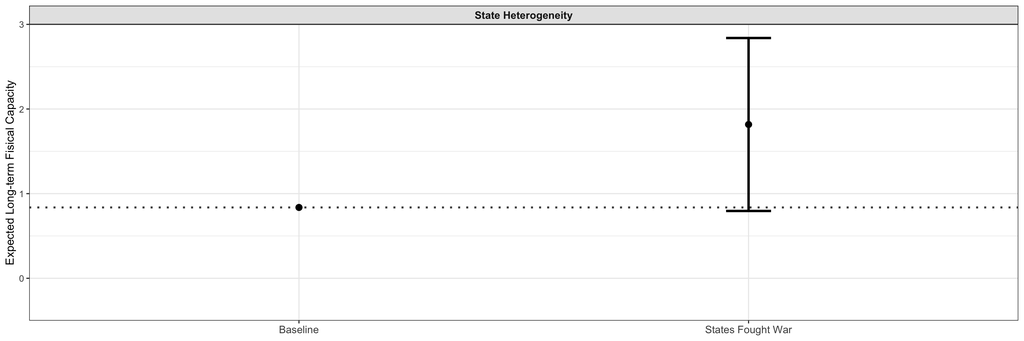

```r
controls_wc <- controls_wc %>%
  mutate(ever_war = if_else(yr_war > 0, 1, 0))

m_war_dummy <- feols(
  as.formula(paste("avg_pit_95_05 ~  ever_war +", xctrl)),
  data = controls_wc,
  vcov = "HC1"
)

tt <- tidy(m_war_dummy)
war_var <- "ever_war"

# coefficients and SEs
b0   <- tt$estimate[tt$term == "(Intercept)"]
b1   <- tt$estimate[tt$term == war_var]
se1  <- tt$std.error[tt$term == war_var]
z    <- 1.96

# EV for "States Fought War" and its CI using ONLY SE(b1)
mu_war  <- b0 + b1
lb_war  <- mu_war - z * se1
ub_war  <- mu_war + z * se1

# plotting data: baseline has no CI (NA), war has CI
df_plot <- tibble(
  status   = factor(c("Baseline", "States Fought War"),
                    levels = c("Baseline", "States Fought War")),
  estimate = c(b0, mu_war),
  lb       = c(NA,  lb_war),
  ub       = c(NA,  ub_war)
)

df_plot_hdr <- df_plot %>% mutate(panel = "State Heterogeneity")

ylim = c(-0.5,3)
p1_dummy <- ggplot(df_plot_hdr, aes(x = status, y = estimate)) +
      geom_hline(yintercept = b0, linetype = "dotted", colour = "grey30", linewidth = 1) +
      geom_errorbar(aes(ymin = lb, ymax = ub), width = 0.10, linewidth = 1.2, na.rm = TRUE) +
      geom_point(size = 2.8, na.rm = TRUE) +
      scale_y_continuous(limits = ylim, expand = expansion(mult = 0)) +
      facet_wrap(~ panel) +                               # <-- grey header via facet strip
      labs(x = NULL, y = "Expected Long-term Fisical Capacity") +   # title handled by strip
      theme_bw(base_size = 12) +
      theme(
        strip.background = element_rect(fill = "grey90", colour = "black"),
        strip.text       = element_text(size = 11, face = "bold"),
        axis.text.x      = element_text(size = 11),
        plot.title       = element_blank()
        )

print(p1_dummy)
```

## Figure 3 WARS version

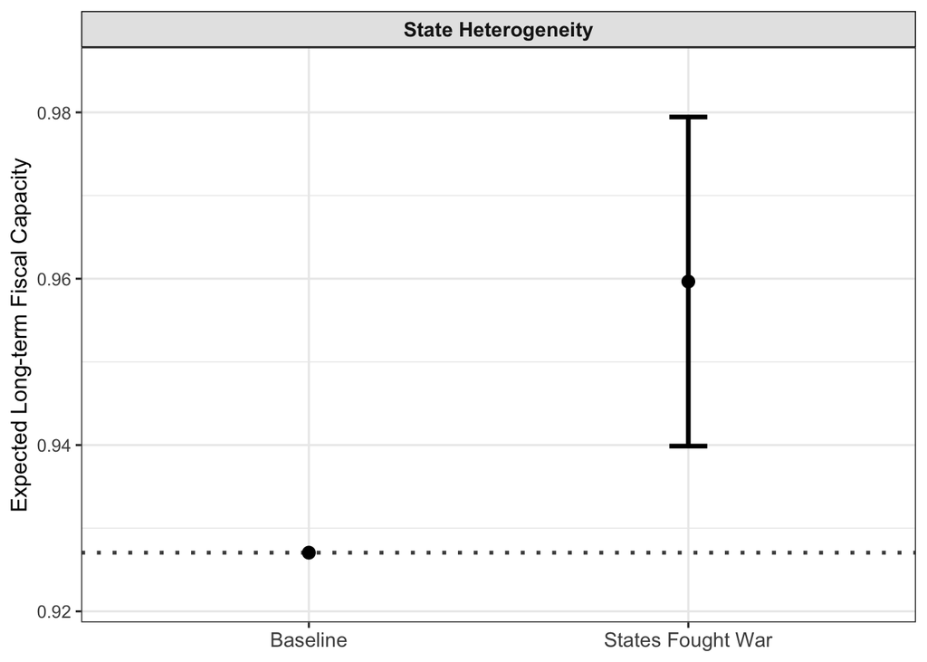

```r
# Assuming you have these data frames available:
# war, df_RR, df_GCD, controls, and xctrl defined

war_crisis_95 <- war %>%
  # First filter to your desired time range
  filter(year >= 1823, year <= 1995) %>%
  # Then create complete country-year combinations for existing countries only
  group_by(iso3) %>%
  complete(year = 1823:1995) %>%
  ungroup() %>%
  mutate(
    flag_RR   = as.integer(year %in% df_RR$Year),
    flag_GCD  = as.integer(year %in% df_GCD$Year),
    # Impute 0 for missing war status
    across(c(is_inter, is_intra), ~ ifelse(is.na(.), 0, .)),
    at_war = as.integer(is_inter == 1 | is_intra == 1)
  )

# --- cross-section ---
war_crisis_95 <- war_crisis_95 %>%
  group_by(iso3) %>%
  summarise(
    yr_war   = sum(at_war,       na.rm = TRUE),
    yr_inter = sum(is_inter,  na.rm = TRUE),
    yr_intra = sum(is_intra,  na.rm = TRUE),

    yr_in_crisis_RR        = sum(at_war      & flag_RR  == 1L, na.rm = TRUE),
    yr_in_crisis_RR_inter  = sum(is_inter & flag_RR  == 1L, na.rm = TRUE),
    yr_in_crisis_RR_intra  = sum(is_intra & flag_RR  == 1L, na.rm = TRUE),

    yr_in_crisis_GCD       = sum(at_war      & flag_GCD == 1L, na.rm = TRUE),
    yr_in_crisis_GCD_inter = sum(is_inter & flag_GCD == 1L, na.rm = TRUE),
    yr_in_crisis_GCD_intra = sum(is_intra & flag_GCD == 1L, na.rm = TRUE),
    .groups = "drop"
  )

# Impute 0 for missing values
war_crisis_95[is.na(war_crisis_95)] <- 0

controls_95 <- controls %>%
  left_join(war_crisis_95, by = "iso3")

# Identify which columns in controls_95 are from war_crisis_95
vars_from_war <- intersect(names(controls_95), names(war_crisis_95))

# Impute 0 for all NAs in those columns
controls_95[vars_from_war] <- lapply(controls_95[vars_from_war], function(x) {
  x[is.na(x)] <- 0
  x
})

# Check if model runs - added error handling
if(!exists("xctrl")) {
  stop("xctrl (control variables) not defined")
}

m_war_95 <- feols(
  as.formula(paste("avg_pit_95_05 ~  yr_war +", xctrl)),
  data = controls_95,
  vcov = "HC1"
)

tt <- tidy(m_war_95)
war_var <- "yr_war"

# FIXED: Proper prediction with variance calculation
b0   <- tt$estimate[tt$term == "(Intercept)"]
b1   <- tt$estimate[tt$term == war_var]
se1  <- tt$std.error[tt$term == war_var]
z    <- 1.96

# For "Baseline" - just the intercept
mu_baseline <- b0
# For "States Fought War" - intercept + coefficient
mu_war  <- b0 + b1

# FIXED: Calculate proper standard errors for predictions
# This assumes you want the SE for the prediction when yr_war = 1
# In a simple case without other covariates affecting the variance:
se_war <- se1  # This is simplified - in reality should account for covariate variance

lb_war  <- mu_war - z * se_war
ub_war  <- mu_war + z * se_war

# plotting data
df_plot_95 <- tibble(
  status   = factor(c("Baseline", "States Fought War"),
                    levels = c("Baseline", "States Fought War")),
  estimate = c(mu_baseline, mu_war),
  lb       = c(NA, lb_war),
  ub       = c(NA, ub_war)
)

df_plot_95 <- df_plot_95 %>% mutate(panel = "State Heterogeneity")

# FIXED: More flexible y-axis limits
ylim <- range(c(df_plot_95$estimate, df_plot_95$lb, df_plot_95$ub), na.rm = TRUE)
# Add some padding
ylim <- ylim + c(-0.1, 0.1) * diff(ylim)

p1_95 <- ggplot(df_plot_95, aes(x = status, y = estimate)) +
  geom_hline(yintercept = mu_baseline, linetype = "dotted", colour = "grey30", linewidth = 1) +
  geom_errorbar(aes(ymin = lb, ymax = ub), width = 0.10, linewidth = 1.2, na.rm = TRUE) +
  geom_point(size = 2.8, na.rm = TRUE) +
  scale_y_continuous(limits = ylim, expand = expansion(mult = 0.05)) +
  facet_wrap(~ panel) +
  labs(x = NULL, y = "Expected Long-term Fiscal Capacity") +  # Fixed typo: "Fisical" -> "Fiscal"
  theme_bw(base_size = 12) +
  theme(
    strip.background = element_rect(fill = "grey90", colour = "black"),
    strip.text       = element_text(size = 11, face = "bold"),
    axis.text.x      = element_text(size = 11),
    plot.title       = element_blank()
  )

p1_95
```